# Callout: Response

J.D. Raffa

Nov. 1, 2018

This analysis was done in response to a letter submitted by Drs. Ofoma and Keithireddy about our paper.

The main concern was related to the use of the discharge delay > 24 h exposure. This work explores the sensitivity of the conclusions to this parametrization fitting natural cubic splines and a more granular binned approach.

They had also request more information about the different groups with longer/shorter discharge delays, and this was actually looked at in our previous output document (analysis_paper.html), but is repeated here for completeness.

```
## [1] 27288
```

```
## [1] 27221
```

```
## [1] 11038
```

```
## [1] 11038
```

```
## [1] 9673
```

Below are the Overall patient characteristics.

Patient Characteristics Overall

| variable_name | level | Overall |
| --- | --- | --- |
| n |  | 9673 |
| micu (%) | 1 | 9673 (100.0) |
| age_nohipaa (mean (sd)) |  | 63.78 (18.11) |
| callout_month (%) | 1 | 774 ( 8.0) |
|  | 2 | 738 ( 7.6) |
|  | 3 | 733 ( 7.6) |
|  | 4 | 726 ( 7.5) |
|  | 5 | 794 ( 8.2) |
|  | 6 | 745 ( 7.7) |
|  | 7 | 779 ( 8.1) |
|  | 8 | 877 ( 9.1) |
|  | 9 | 851 ( 8.8) |
|  | 10 | 914 ( 9.4) |
|  | 11 | 823 ( 8.5) |
|  | 12 | 919 ( 9.5) |
| female (%) | 0 | 4956 ( 51.2) |
|  | 1 | 4717 ( 48.8) |
| request_tele (%) | 0 | 6318 ( 65.3) |
|  | 1 | 3355 ( 34.7) |
| request_resp (%) | 0 | 9514 ( 98.4) |
|  | 1 | 159 ( 1.6) |
| request_cdiff (%) | 0 | 9190 ( 95.0) |
|  | 1 | 483 ( 5.0) |
| request_mrsa (%) | 0 | 8405 ( 86.9) |
|  | 1 | 1268 ( 13.1) |
| request_vre (%) | 0 | 9182 ( 94.9) |
|  | 1 | 491 ( 5.1) |
| oasis (mean (sd)) |  | 29.84 (7.30) |
| elixhauser_hospital (mean (sd)) |  | 3.54 (7.28) |
| ethnicity (%) | White | 6910 ( 71.4) |
|  | African American/Black | 1494 ( 15.4) |
|  | Other | 1269 ( 13.1) |
| MED_SERVICE (%) | FALSE | 692 ( 7.2) |
|  | TRUE | 8981 ( 92.8) |
| HOSP_FREE_DAYS (median [IQR]) |  | 24.12 [20.29, 26.02] |
| callout_dayofweek (%) | friday | 1442 ( 14.9) |
|  | monday | 1300 ( 13.4) |
|  | saturday | 1292 ( 13.4) |
|  | sunday | 1267 ( 13.1) |
|  | thursday | 1412 ( 14.6) |
|  | tuesday | 1422 ( 14.7) |
|  | wednesday | 1538 ( 15.9) |
| CALLOUT_DURING_NIGHT (%) | FALSE | 9607 ( 99.3) |
|  | TRUE | 66 ( 0.7) |
| CALLOUT_DURING_ROUNDS (%) | FALSE | 3816 ( 39.5) |
|  | TRUE | 5857 ( 60.5) |
| DISCHARGEDELAY_HOURS (mean (sd)) |  | 10.37 (10.28) |
| hourofcallout2 (median [IQR]) |  | 11.40 [10.12, 13.17] |
| PROPFULL_BEDS (mean (sd)) |  | 0.91 (0.09) |
| postcalldaycat2 (%) | 0 | 7800 ( 80.6) |
|  | [1,5] | 1873 ( 19.4) |
| hospitaldeath (%) | 0 | 9140 ( 94.5) |
|  | 1 | 533 ( 5.5) |
| los_preicu_days (median [IQR]) |  | 0.00 [0.00, 0.15] |
| los_post_callout_days (median [IQR]) |  | 4.16 [2.28, 7.24] |
| los_post_icu_days (median [IQR]) |  | 3.80 [1.95, 6.89] |
| los_pre_callout_days (median [IQR]) |  | 1.77 [0.94, 3.68] |
| callout_year (%) | 2005 | 376 ( 3.9) |
|  | 2006 | 1070 ( 11.1) |
|  | 2007 | 1417 ( 14.6) |
|  | 2008 | 1638 ( 16.9) |
|  | 2009 | 1668 ( 17.2) |
|  | 2010 | 1739 ( 18.0) |
|  | 2011 | 1765 ( 18.2) |

# Question 1: Who has long discharge delays?

Patient Characteristics By Discharge Delay Categories (Hours)

| variable_name | level | [ 0, 4) | [ 4, 8) | [ 8, 24) | [ 24,130] | p | test |
| --- | --- | --- | --- | --- | --- | --- | --- |
| n |  | 1308 | 4348 | 3006 | 1011 |  |  |
| micu (%) | 1 | 1308 (100.0) | 4348 (100.0) | 3006 (100.0) | 1011 (100.0) | NA |  |
| age_nohipaa (mean (sd)) |  | 63.16 (17.96) | 63.60 (18.09) | 64.17 (18.23) | 64.20 (18.05) | 0.280 |  |
| callout_month (%) | 1 | 113 ( 8.6) | 334 ( 7.7) | 238 ( 7.9) | 89 ( 8.8) | <0.001 |  |
|  | 2 | 95 ( 7.3) | 296 ( 6.8) | 257 ( 8.5) | 90 ( 8.9) |  |  |
|  | 3 | 105 ( 8.0) | 365 ( 8.4) | 212 ( 7.1) | 51 ( 5.0) |  |  |
|  | 4 | 124 ( 9.5) | 354 ( 8.1) | 193 ( 6.4) | 55 ( 5.4) |  |  |
|  | 5 | 103 ( 7.9) | 374 ( 8.6) | 251 ( 8.3) | 66 ( 6.5) |  |  |
|  | 6 | 110 ( 8.4) | 347 ( 8.0) | 214 ( 7.1) | 74 ( 7.3) |  |  |
|  | 7 | 104 ( 8.0) | 371 ( 8.5) | 233 ( 7.8) | 71 ( 7.0) |  |  |
|  | 8 | 99 ( 7.6) | 379 ( 8.7) | 290 ( 9.6) | 109 ( 10.8) |  |  |
|  | 9 | 105 ( 8.0) | 328 ( 7.5) | 292 ( 9.7) | 126 ( 12.5) |  |  |
|  | 10 | 112 ( 8.6) | 379 ( 8.7) | 309 ( 10.3) | 114 ( 11.3) |  |  |
|  | 11 | 100 ( 7.6) | 359 ( 8.3) | 257 ( 8.5) | 107 ( 10.6) |  |  |
|  | 12 | 138 ( 10.6) | 462 ( 10.6) | 260 ( 8.6) | 59 ( 5.8) |  |  |
| female (%) | 0 | 682 ( 52.1) | 2205 ( 50.7) | 1523 ( 50.7) | 546 ( 54.0) | 0.221 |  |
|  | 1 | 626 ( 47.9) | 2143 ( 49.3) | 1483 ( 49.3) | 465 ( 46.0) |  |  |
| request_tele (%) | 0 | 808 ( 61.8) | 2836 ( 65.2) | 2004 ( 66.7) | 670 ( 66.3) | 0.018 |  |
|  | 1 | 500 ( 38.2) | 1512 ( 34.8) | 1002 ( 33.3) | 341 ( 33.7) |  |  |
| request_resp (%) | 0 | 1292 ( 98.8) | 4274 ( 98.3) | 2955 ( 98.3) | 993 ( 98.2) | 0.639 |  |
|  | 1 | 16 ( 1.2) | 74 ( 1.7) | 51 ( 1.7) | 18 ( 1.8) |  |  |
| request_cdiff (%) | 0 | 1257 ( 96.1) | 4139 ( 95.2) | 2854 ( 94.9) | 940 ( 93.0) | 0.006 |  |
|  | 1 | 51 ( 3.9) | 209 ( 4.8) | 152 ( 5.1) | 71 ( 7.0) |  |  |
| request_mrsa (%) | 0 | 1184 ( 90.5) | 3804 ( 87.5) | 2588 ( 86.1) | 829 ( 82.0) | <0.001 |  |
|  | 1 | 124 ( 9.5) | 544 ( 12.5) | 418 ( 13.9) | 182 ( 18.0) |  |  |
| request_vre (%) | 0 | 1235 ( 94.4) | 4144 ( 95.3) | 2860 ( 95.1) | 943 ( 93.3) | 0.045 |  |
|  | 1 | 73 ( 5.6) | 204 ( 4.7) | 146 ( 4.9) | 68 ( 6.7) |  |  |
| oasis (mean (sd)) |  | 29.38 (7.22) | 29.78 (7.37) | 30.01 (7.15) | 30.21 (7.49) | 0.021 |  |
| elixhauser_hospital (mean (sd)) |  | 3.30 (7.12) | 3.49 (7.23) | 3.52 (7.35) | 4.15 (7.45) | 0.031 |  |
| ethnicity (%) | White | 962 ( 73.5) | 3107 ( 71.5) | 2114 ( 70.3) | 727 ( 71.9) | 0.534 |  |
|  | African American/Black | 190 ( 14.5) | 673 ( 15.5) | 481 ( 16.0) | 150 ( 14.8) |  |  |
|  | Other | 156 ( 11.9) | 568 ( 13.1) | 411 ( 13.7) | 134 ( 13.3) |  |  |
| MED_SERVICE (%) | FALSE | 155 ( 11.9) | 327 ( 7.5) | 156 ( 5.2) | 54 ( 5.3) | <0.001 |  |
|  | TRUE | 1153 ( 88.1) | 4021 ( 92.5) | 2850 ( 94.8) | 957 ( 94.7) |  |  |
| HOSP_FREE_DAYS (median [IQR]) |  | 24.05 [20.72, 25.98] | 24.05 [20.18, 25.97] | 24.25 [21.03, 26.09] | 24.16 [19.63, 26.23] | <0.001 | nonnorm |
| callout_dayofweek (%) | friday | 165 ( 12.6) | 641 ( 14.7) | 480 ( 16.0) | 156 ( 15.4) | <0.001 |  |
|  | monday | 208 ( 15.9) | 612 ( 14.1) | 370 ( 12.3) | 110 ( 10.9) |  |  |
|  | saturday | 146 ( 11.2) | 594 ( 13.7) | 442 ( 14.7) | 110 ( 10.9) |  |  |
|  | sunday | 234 ( 17.9) | 611 ( 14.1) | 326 ( 10.8) | 96 ( 9.5) |  |  |
|  | thursday | 172 ( 13.1) | 580 ( 13.3) | 467 ( 15.5) | 193 ( 19.1) |  |  |
|  | tuesday | 185 ( 14.1) | 618 ( 14.2) | 450 ( 15.0) | 169 ( 16.7) |  |  |
|  | wednesday | 198 ( 15.1) | 692 ( 15.9) | 471 ( 15.7) | 177 ( 17.5) |  |  |
| CALLOUT_DURING_NIGHT (%) | FALSE | 1293 ( 98.9) | 4331 ( 99.6) | 2976 ( 99.0) | 1007 ( 99.6) | 0.002 |  |
|  | TRUE | 15 ( 1.1) | 17 ( 0.4) | 30 ( 1.0) | 4 ( 0.4) |  |  |
| CALLOUT_DURING_ROUNDS (%) | FALSE | 765 ( 58.5) | 1744 ( 40.1) | 862 ( 28.7) | 445 ( 44.0) | <0.001 |  |
|  | TRUE | 543 ( 41.5) | 2604 ( 59.9) | 2144 ( 71.3) | 566 ( 56.0) |  |  |
| DISCHARGEDELAY_HOURS (mean (sd)) |  | 3.07 (0.70) | 5.95 (1.11) | 11.40 (3.49) | 35.80 (12.87) | <0.001 |  |
| hourofcallout2 (median [IQR]) |  | 12.60 [10.71, 15.25] | 11.52 [10.35, 13.07] | 10.72 [9.47, 12.17] | 11.60 [10.39, 13.88] | <0.001 | nonnorm |
| PROPFULL_BEDS (mean (sd)) |  | 0.89 (0.09) | 0.90 (0.09) | 0.92 (0.08) | 0.95 (0.07) | <0.001 |  |
| postcalldaycat2 (%) | 0 | 1284 ( 98.2) | 4211 ( 96.8) | 2305 ( 76.7) | 0 ( 0.0) | <0.001 |  |
|  | [1,5] | 24 ( 1.8) | 137 ( 3.2) | 701 ( 23.3) | 1011 (100.0) |  |  |
| hospitaldeath (%) | 0 | 1233 ( 94.3) | 4117 ( 94.7) | 2848 ( 94.7) | 942 ( 93.2) | 0.243 |  |
|  | 1 | 75 ( 5.7) | 231 ( 5.3) | 158 ( 5.3) | 69 ( 6.8) |  |  |
| los_preicu_days (median [IQR]) |  | 0.00 [0.00, 0.38] | 0.00 [0.00, 0.15] | 0.00 [0.00, 0.10] | 0.00 [0.00, 0.07] | 0.012 | nonnorm |
| los_post_callout_days (median [IQR]) |  | 3.97 [2.11, 6.99] | 4.14 [2.26, 7.18] | 4.14 [2.31, 7.17] | 5.13 [3.11, 9.06] | <0.001 | nonnorm |
| los_post_icu_days (median [IQR]) |  | 3.83 [1.97, 6.85] | 3.89 [2.00, 6.94] | 3.67 [1.88, 6.71] | 3.71 [1.68, 7.33] | <0.001 | nonnorm |
| los_pre_callout_days (median [IQR]) |  | 1.80 [0.98, 3.57] | 1.78 [0.95, 3.72] | 1.76 [0.89, 3.62] | 1.73 [0.88, 3.76] | 0.391 | nonnorm |
| callout_year (%) | 2005 | 27 ( 2.1) | 164 ( 3.8) | 113 ( 3.8) | 72 ( 7.1) | <0.001 |  |
|  | 2006 | 102 ( 7.8) | 404 ( 9.3) | 297 ( 9.9) | 267 ( 26.4) |  |  |
|  | 2007 | 140 ( 10.7) | 521 ( 12.0) | 474 ( 15.8) | 282 ( 27.9) |  |  |
|  | 2008 | 229 ( 17.5) | 786 ( 18.1) | 516 ( 17.2) | 107 ( 10.6) |  |  |
|  | 2009 | 308 ( 23.5) | 811 ( 18.7) | 475 ( 15.8) | 74 ( 7.3) |  |  |
|  | 2010 | 222 ( 17.0) | 779 ( 17.9) | 608 ( 20.2) | 130 ( 12.9) |  |  |
|  | 2011 | 280 ( 21.4) | 883 ( 20.3) | 523 ( 17.4) | 79 ( 7.8) |  |  |

Patient Characteristics By Discharge Delay Categories (Hours)

| variable_name | level | [ 0.238, 24.000) | [ 24.000,129.566] | p | test |
| --- | --- | --- | --- | --- | --- |
| n |  | 8662 | 1011 |  |  |
| micu (%) | 1 | 8662 (100.0) | 1011 (100.0) | NA |  |
| age_nohipaa (mean (sd)) |  | 63.73 (18.12) | 64.20 (18.05) | 0.438 |  |
| callout_month (%) | 1 | 685 ( 7.9) | 89 ( 8.8) | <0.001 |  |
|  | 2 | 648 ( 7.5) | 90 ( 8.9) |  |  |
|  | 3 | 682 ( 7.9) | 51 ( 5.0) |  |  |
|  | 4 | 671 ( 7.7) | 55 ( 5.4) |  |  |
|  | 5 | 728 ( 8.4) | 66 ( 6.5) |  |  |
|  | 6 | 671 ( 7.7) | 74 ( 7.3) |  |  |
|  | 7 | 708 ( 8.2) | 71 ( 7.0) |  |  |
|  | 8 | 768 ( 8.9) | 109 ( 10.8) |  |  |
|  | 9 | 725 ( 8.4) | 126 ( 12.5) |  |  |
|  | 10 | 800 ( 9.2) | 114 ( 11.3) |  |  |
|  | 11 | 716 ( 8.3) | 107 ( 10.6) |  |  |
|  | 12 | 860 ( 9.9) | 59 ( 5.8) |  |  |
| female (%) | 0 | 4410 ( 50.9) | 546 ( 54.0) | 0.067 |  |
|  | 1 | 4252 ( 49.1) | 465 ( 46.0) |  |  |
| request_tele (%) | 0 | 5648 ( 65.2) | 670 ( 66.3) | 0.523 |  |
|  | 1 | 3014 ( 34.8) | 341 ( 33.7) |  |  |
| request_resp (%) | 0 | 8521 ( 98.4) | 993 ( 98.2) | 0.818 |  |
|  | 1 | 141 ( 1.6) | 18 ( 1.8) |  |  |
| request_cdiff (%) | 0 | 8250 ( 95.2) | 940 ( 93.0) | 0.002 |  |
|  | 1 | 412 ( 4.8) | 71 ( 7.0) |  |  |
| request_mrsa (%) | 0 | 7576 ( 87.5) | 829 ( 82.0) | <0.001 |  |
|  | 1 | 1086 ( 12.5) | 182 ( 18.0) |  |  |
| request_vre (%) | 0 | 8239 ( 95.1) | 943 ( 93.3) | 0.014 |  |
|  | 1 | 423 ( 4.9) | 68 ( 6.7) |  |  |
| oasis (mean (sd)) |  | 29.80 (7.27) | 30.21 (7.49) | 0.085 |  |
| elixhauser_hospital (mean (sd)) |  | 3.47 (7.25) | 4.15 (7.45) | 0.005 |  |
| ethnicity (%) | White | 6183 ( 71.4) | 727 ( 71.9) | 0.851 |  |
|  | African American/Black | 1344 ( 15.5) | 150 ( 14.8) |  |  |
|  | Other | 1135 ( 13.1) | 134 ( 13.3) |  |  |
| MED_SERVICE (%) | FALSE | 638 ( 7.4) | 54 ( 5.3) | 0.022 |  |
|  | TRUE | 8024 ( 92.6) | 957 ( 94.7) |  |  |
| HOSP_FREE_DAYS (median [IQR]) |  | 24.11 [20.35, 26.01] | 24.16 [19.63, 26.23] | 0.035 | nonnorm |
| callout_dayofweek (%) | friday | 1286 ( 14.8) | 156 ( 15.4) | <0.001 |  |
|  | monday | 1190 ( 13.7) | 110 ( 10.9) |  |  |
|  | saturday | 1182 ( 13.6) | 110 ( 10.9) |  |  |
|  | sunday | 1171 ( 13.5) | 96 ( 9.5) |  |  |
|  | thursday | 1219 ( 14.1) | 193 ( 19.1) |  |  |
|  | tuesday | 1253 ( 14.5) | 169 ( 16.7) |  |  |
|  | wednesday | 1361 ( 15.7) | 177 ( 17.5) |  |  |
| CALLOUT_DURING_NIGHT (%) | FALSE | 8600 ( 99.3) | 1007 ( 99.6) | 0.333 |  |
|  | TRUE | 62 ( 0.7) | 4 ( 0.4) |  |  |
| CALLOUT_DURING_ROUNDS (%) | FALSE | 3371 ( 38.9) | 445 ( 44.0) | 0.002 |  |
|  | TRUE | 5291 ( 61.1) | 566 ( 56.0) |  |  |
| DISCHARGEDELAY_HOURS (mean (sd)) |  | 7.40 (3.79) | 35.80 (12.87) | <0.001 |  |
| hourofcallout2 (median [IQR]) |  | 11.37 [10.08, 13.08] | 11.60 [10.39, 13.88] | <0.001 | nonnorm |
| PROPFULL_BEDS (mean (sd)) |  | 0.91 (0.09) | 0.95 (0.07) | <0.001 |  |
| postcalldaycat2 (%) | 0 | 7800 ( 90.0) | 0 ( 0.0) | <0.001 |  |
|  | [1,5] | 862 ( 10.0) | 1011 (100.0) |  |  |
| hospitaldeath (%) | 0 | 8198 ( 94.6) | 942 ( 93.2) | 0.062 |  |
|  | 1 | 464 ( 5.4) | 69 ( 6.8) |  |  |
| los_preicu_days (median [IQR]) |  | 0.00 [0.00, 0.16] | 0.00 [0.00, 0.07] | 0.459 | nonnorm |
| los_post_callout_days (median [IQR]) |  | 4.12 [2.26, 7.15] | 5.13 [3.11, 9.06] | <0.001 | nonnorm |
| los_post_icu_days (median [IQR]) |  | 3.81 [1.97, 6.86] | 3.71 [1.68, 7.33] | 0.012 | nonnorm |
| los_pre_callout_days (median [IQR]) |  | 1.77 [0.94, 3.68] | 1.73 [0.88, 3.76] | 0.541 | nonnorm |
| callout_year (%) | 2005 | 304 ( 3.5) | 72 ( 7.1) | <0.001 |  |
|  | 2006 | 803 ( 9.3) | 267 ( 26.4) |  |  |
|  | 2007 | 1135 ( 13.1) | 282 ( 27.9) |  |  |
|  | 2008 | 1531 ( 17.7) | 107 ( 10.6) |  |  |
|  | 2009 | 1594 ( 18.4) | 74 ( 7.3) |  |  |
|  | 2010 | 1609 ( 18.6) | 130 ( 12.9) |  |  |
|  | 2011 | 1686 ( 19.5) | 79 ( 7.8) |  |  |

We fit a logistic regression model with:

1. Demographics: age, sex,
2. Requests: tele, resp, mrsa, cdiff, vre
3. Adjustment for severity/comoribidity/icu los: oasis, exlixhauser, los_pre_callout_days
4. Possible structural/admin variables: DOW, month, year.
5. Census variables: type of bed requested, proportion of hospital beds is use.

| variable_name | level | 0 | 1 | p | test |
| --- | --- | --- | --- | --- | --- |
| n |  | 9140 | 533 |  |  |
| micu (%) | 1 | 9140 (100.0) | 533 (100.0) | NA |  |
| age_nohipaa (mean (sd)) |  | 63.46 (18.19) | 69.25 (15.78) | <0.001 |  |
| callout_month (%) | 1 | 734 ( 8.0) | 40 ( 7.5) | 0.485 |  |
|  | 2 | 699 ( 7.6) | 39 ( 7.3) |  |  |
|  | 3 | 680 ( 7.4) | 53 ( 9.9) |  |  |
|  | 4 | 681 ( 7.5) | 45 ( 8.4) |  |  |
|  | 5 | 751 ( 8.2) | 43 ( 8.1) |  |  |
|  | 6 | 705 ( 7.7) | 40 ( 7.5) |  |  |
|  | 7 | 737 ( 8.1) | 42 ( 7.9) |  |  |
|  | 8 | 820 ( 9.0) | 57 ( 10.7) |  |  |
|  | 9 | 808 ( 8.8) | 43 ( 8.1) |  |  |
|  | 10 | 870 ( 9.5) | 44 ( 8.3) |  |  |
|  | 11 | 788 ( 8.6) | 35 ( 6.6) |  |  |
|  | 12 | 867 ( 9.5) | 52 ( 9.8) |  |  |
| female (%) | 0 | 4662 ( 51.0) | 294 ( 55.2) | 0.069 |  |
|  | 1 | 4478 ( 49.0) | 239 ( 44.8) |  |  |
| request_tele (%) | 0 | 5943 ( 65.0) | 375 ( 70.4) | 0.014 |  |
|  | 1 | 3197 ( 35.0) | 158 ( 29.6) |  |  |
| request_resp (%) | 0 | 8987 ( 98.3) | 527 ( 98.9) | 0.428 |  |
|  | 1 | 153 ( 1.7) | 6 ( 1.1) |  |  |
| request_cdiff (%) | 0 | 8709 ( 95.3) | 481 ( 90.2) | <0.001 |  |
|  | 1 | 431 ( 4.7) | 52 ( 9.8) |  |  |
| request_mrsa (%) | 0 | 7948 ( 87.0) | 457 ( 85.7) | 0.457 |  |
|  | 1 | 1192 ( 13.0) | 76 ( 14.3) |  |  |
| request_vre (%) | 0 | 8704 ( 95.2) | 478 ( 89.7) | <0.001 |  |
|  | 1 | 436 ( 4.8) | 55 ( 10.3) |  |  |
| oasis (mean (sd)) |  | 29.55 (7.14) | 34.79 (8.12) | <0.001 |  |
| elixhauser_hospital (mean (sd)) |  | 3.26 (7.20) | 8.38 (6.93) | <0.001 |  |
| ethnicity (%) | White | 6515 ( 71.3) | 395 ( 74.1) | 0.008 |  |
|  | African American/Black | 1436 ( 15.7) | 58 ( 10.9) |  |  |
|  | Other | 1189 ( 13.0) | 80 ( 15.0) |  |  |
| MED_SERVICE (%) | FALSE | 659 ( 7.2) | 33 ( 6.2) | 0.423 |  |
|  | TRUE | 8481 ( 92.8) | 500 ( 93.8) |  |  |
| HOSP_FREE_DAYS (median [IQR]) |  | 24.24 [21.23, 26.06] | 0.00 [0.00, 0.00] | <0.001 | nonnorm |
| callout_dayofweek (%) | friday | 1368 ( 15.0) | 74 ( 13.9) | 0.249 |  |
|  | monday | 1227 ( 13.4) | 73 ( 13.7) |  |  |
|  | saturday | 1229 ( 13.4) | 63 ( 11.8) |  |  |
|  | sunday | 1202 ( 13.2) | 65 ( 12.2) |  |  |
|  | thursday | 1326 ( 14.5) | 86 ( 16.1) |  |  |
|  | tuesday | 1326 ( 14.5) | 96 ( 18.0) |  |  |
|  | wednesday | 1462 ( 16.0) | 76 ( 14.3) |  |  |
| CALLOUT_DURING_NIGHT (%) | FALSE | 9081 ( 99.4) | 526 ( 98.7) | 0.121 |  |
|  | TRUE | 59 ( 0.6) | 7 ( 1.3) |  |  |
| CALLOUT_DURING_ROUNDS (%) | FALSE | 3583 ( 39.2) | 233 ( 43.7) | 0.043 |  |
|  | TRUE | 5557 ( 60.8) | 300 ( 56.3) |  |  |
| DISCHARGEDELAY_HOURS (mean (sd)) |  | 10.31 (10.16) | 11.47 (12.12) | 0.011 |  |
| hourofcallout2 (median [IQR]) |  | 11.38 [10.10, 13.15] | 11.60 [10.23, 13.52] | 0.076 | nonnorm |
| PROPFULL_BEDS (mean (sd)) |  | 0.91 (0.09) | 0.91 (0.09) | 0.543 |  |
| postcalldaycat2 (%) | 0 | 7393 ( 80.9) | 407 ( 76.4) | 0.012 |  |
|  | [1,5] | 1747 ( 19.1) | 126 ( 23.6) |  |  |
| los_preicu_days (median [IQR]) |  | 0.00 [0.00, 0.13] | 0.00 [0.00, 1.87] | <0.001 | nonnorm |
| los_post_callout_days (median [IQR]) |  | 4.13 [2.27, 7.12] | 6.86 [2.87, 14.67] | <0.001 | nonnorm |
| los_post_icu_days (median [IQR]) |  | 3.76 [1.94, 6.77] | 6.36 [2.59, 14.16] | <0.001 | nonnorm |
| los_pre_callout_days (median [IQR]) |  | 1.74 [0.93, 3.55] | 3.48 [1.51, 7.67] | <0.001 | nonnorm |
| callout_year (%) | 2005 | 346 ( 3.8) | 30 ( 5.6) | 0.015 |  |
|  | 2006 | 996 ( 10.9) | 74 ( 13.9) |  |  |
|  | 2007 | 1329 ( 14.5) | 88 ( 16.5) |  |  |
|  | 2008 | 1561 ( 17.1) | 77 ( 14.4) |  |  |
|  | 2009 | 1586 ( 17.4) | 82 ( 15.4) |  |  |
|  | 2010 | 1639 ( 17.9) | 100 ( 18.8) |  |  |
|  | 2011 | 1683 ( 18.4) | 82 ( 15.4) |  |  |

```
## Single term deletions
##
## Model:
## hospitaldeath ~ ns(DISCHARGEDELAY_HOURS, knots = c(6, 12, 24,
##     36, 48)) + +cut2(oasis, g = 3) + cut2(age_nohipaa, g = 3) +
##     female + request_tele + request_resp + request_mrsa + request_vre +
##     request_cdiff + cut2(elixhauser_hospital, g = 3) + cut2(los_pre_callout_days,
##     c(1, 3, 7, 28)) + as.factor(callout_month) + as.factor(callout_year) +
##     as.factor(callout_dayofweek) + as.factor(callout_wardid ==
##     1) * cut2(PROPFULL_BEDS, c(0.9, 1)) + MED_SERVICE + relevel(cut2(hourofcallout2,
##     c(7, 12, 19)), "[ 7.000,12.000)")
##                                                                Df Deviance
## <none>                                                              3547.3
## ns(DISCHARGEDELAY_HOURS, knots = c(6, 12, 24, 36, 48))          6   3548.4
## cut2(oasis, g = 3)                                              2   3660.2
## cut2(age_nohipaa, g = 3)                                        2   3549.4
## female                                                          1   3550.4
## request_tele                                                    1   3557.0
## request_resp                                                    1   3547.4
## request_mrsa                                                    1   3547.6
## request_vre                                                     1   3561.4
## request_cdiff                                                   1   3552.8
## cut2(elixhauser_hospital, g = 3)                                2   3647.5
## cut2(los_pre_callout_days, c(1, 3, 7, 28))                      4   3648.2
## as.factor(callout_month)                                       11   3562.7
## as.factor(callout_year)                                         6   3565.2
## as.factor(callout_dayofweek)                                    6   3554.3
## MED_SERVICE                                                     1   3550.1
## relevel(cut2(hourofcallout2, c(7, 12, 19)), "[ 7.000,12.000)")  3   3552.6
## as.factor(callout_wardid == 1):cut2(PROPFULL_BEDS, c(0.9, 1))   2   3549.5
##                                                                   AIC
## <none>                                                         3657.3
## ns(DISCHARGEDELAY_HOURS, knots = c(6, 12, 24, 36, 48))         3646.4
## cut2(oasis, g = 3)                                             3766.2
## cut2(age_nohipaa, g = 3)                                       3655.4
## female                                                         3658.4
## request_tele                                                   3665.0
## request_resp                                                   3655.4
## request_mrsa                                                   3655.6
## request_vre                                                    3669.4
```

[output cut: 53 more lines]

```
## request_tele                                                   **
## request_resp
## request_mrsa
## request_vre                                                    ***
## request_cdiff                                                  *
## cut2(elixhauser_hospital, g = 3)                               ***
## cut2(los_pre_callout_days, c(1, 3, 7, 28))                     ***
## as.factor(callout_month)
## as.factor(callout_year)                                        **
## as.factor(callout_dayofweek)
## MED_SERVICE                                                    .
## relevel(cut2(hourofcallout2, c(7, 12, 19)), "[ 7.000,12.000)")
## as.factor(callout_wardid == 1):cut2(PROPFULL_BEDS, c(0.9, 1))
## ---
## Signif. codes:  0 '***' 0.001 '**' 0.01 '*' 0.05 '.' 0.1 ' ' 1
```

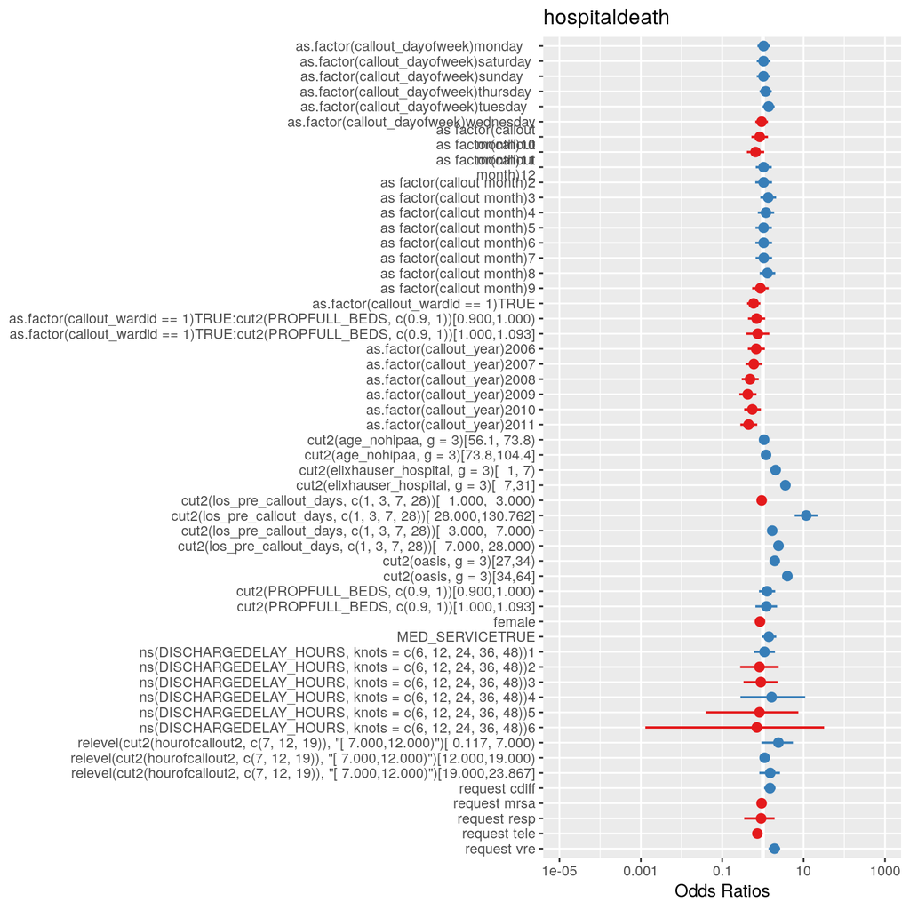

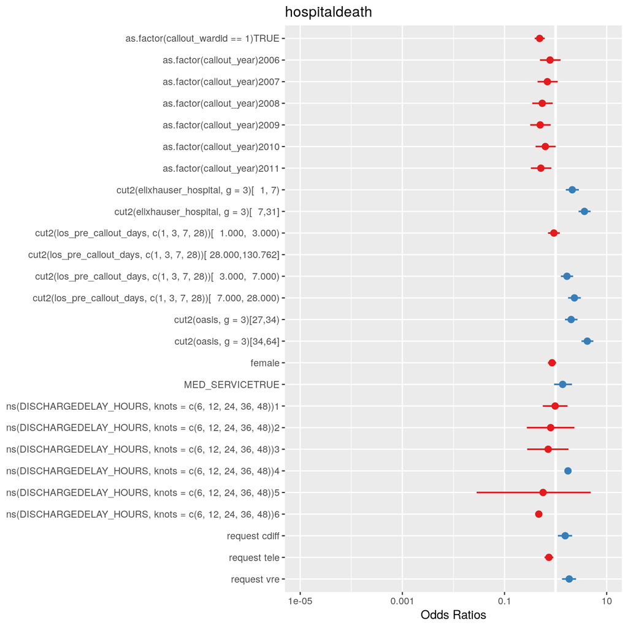

```
## Single term deletions
##
## Model:
## hospitaldeath ~ ns(DISCHARGEDELAY_HOURS, knots = c(6, 12, 24,
##     36, 48)) + cut2(oasis, g = 3) + female + request_tele + request_vre +
##     request_cdiff + cut2(elixhauser_hospital, g = 3) + cut2(los_pre_callout_days,
##     c(1, 3, 7, 28)) + as.factor(callout_year) + as.factor(callout_wardid ==
##     1) + MED_SERVICE
##                                                        Df Deviance    AIC
## <none>                                                      3579.7 3633.7
## ns(DISCHARGEDELAY_HOURS, knots = c(6, 12, 24, 36, 48))  6   3581.1 3623.1
## cut2(oasis, g = 3)                                      2   3714.0 3764.0
## female                                                  1   3582.7 3634.7
## request_tele                                            1   3588.8 3640.8
## request_vre                                             1   3592.7 3644.7
## request_cdiff                                           1   3586.2 3638.2
## cut2(elixhauser_hospital, g = 3)                        2   3687.9 3737.9
## cut2(los_pre_callout_days, c(1, 3, 7, 28))              4   3678.0 3724.0
## as.factor(callout_year)                                 6   3594.7 3636.7
## as.factor(callout_wardid == 1)                          1   3615.1 3667.1
## MED_SERVICE                                             1   3582.3 3634.3
##                                                            LRT  Pr(>Chi)
## <none>
## ns(DISCHARGEDELAY_HOURS, knots = c(6, 12, 24, 36, 48))   1.368 0.9677872
## cut2(oasis, g = 3)                                     134.290 < 2.2e-16
## female                                                   2.939 0.0864834
## request_tele                                             9.061 0.0026114
## request_vre                                             12.951 0.0003198
## request_cdiff                                            6.460 0.0110350
## cut2(elixhauser_hospital, g = 3)                       108.220 < 2.2e-16
## cut2(los_pre_callout_days, c(1, 3, 7, 28))              98.257 < 2.2e-16
## as.factor(callout_year)                                 14.957 0.0205952
## as.factor(callout_wardid == 1)                          35.412 2.669e-09
## MED_SERVICE                                              2.562 0.1094418
##
## <none>
## ns(DISCHARGEDELAY_HOURS, knots = c(6, 12, 24, 36, 48))
## cut2(oasis, g = 3)                                     ***
## female                                                 .
## request_tele                                           **
## request_vre                                            ***
## request_cdiff                                          *
## cut2(elixhauser_hospital, g = 3)                       ***
## cut2(los_pre_callout_days, c(1, 3, 7, 28))             ***
## as.factor(callout_year)                                *
## as.factor(callout_wardid == 1)                         ***
## MED_SERVICE
## ---
## Signif. codes:  0 '***' 0.001 '**' 0.01 '*' 0.05 '.' 0.1 ' ' 1
```

```
## Single term deletions
##
## Model:
## hospitaldeath ~ ns(DISCHARGEDELAY_HOURS, knots = c(6, 12, 24,
##     36, 48)) + +cut2(oasis, g = 3) + cut2(age_nohipaa, g = 3) +
##     female + request_tele + request_resp + request_mrsa + request_vre +
##     request_cdiff + cut2(elixhauser_hospital, g = 3) + cut2(los_pre_callout_days,
##     c(1, 3, 7, 28)) + as.factor(callout_month) + as.factor(callout_year) +
##     as.factor(callout_dayofweek) + as.factor(callout_wardid ==
##     1) * cut2(PROPFULL_BEDS, c(0.9, 1)) + MED_SERVICE + relevel(cut2(hourofcallout2,
##     c(7, 12, 19)), "[ 7.000,12.000)")
##                                                                Df Deviance
## <none>                                                              3547.3
## cut2(oasis, g = 3)                                              2   3660.2
## cut2(age_nohipaa, g = 3)                                        2   3549.4
## female                                                          1   3550.4
## request_tele                                                    1   3557.0
## request_resp                                                    1   3547.4
## request_mrsa                                                    1   3547.6
## request_vre                                                     1   3561.4
## request_cdiff                                                   1   3552.8
## cut2(elixhauser_hospital, g = 3)                                2   3647.5
## cut2(los_pre_callout_days, c(1, 3, 7, 28))                      4   3648.2
## as.factor(callout_month)                                       11   3562.7
## as.factor(callout_year)                                         6   3565.2
## as.factor(callout_dayofweek)                                    6   3554.3
## MED_SERVICE                                                     1   3550.1
## relevel(cut2(hourofcallout2, c(7, 12, 19)), "[ 7.000,12.000)")  3   3552.6
## as.factor(callout_wardid == 1):cut2(PROPFULL_BEDS, c(0.9, 1))   2   3549.5
##                                                                   AIC
## <none>                                                         3657.3
## cut2(oasis, g = 3)                                             3766.2
## cut2(age_nohipaa, g = 3)                                       3655.4
## female                                                         3658.4
## request_tele                                                   3665.0
## request_resp                                                   3655.4
## request_mrsa                                                   3655.6
## request_vre                                                    3669.4
## request_cdiff                                                  3660.8
## cut2(elixhauser_hospital, g = 3)                               3753.5
```

[output cut: 48 more lines]

```
## request_tele                                                   **
## request_resp
## request_mrsa
## request_vre                                                    ***
## request_cdiff                                                  *
## cut2(elixhauser_hospital, g = 3)                               ***
## cut2(los_pre_callout_days, c(1, 3, 7, 28))                     ***
## as.factor(callout_month)
## as.factor(callout_year)                                        **
## as.factor(callout_dayofweek)
## MED_SERVICE                                                    .
## relevel(cut2(hourofcallout2, c(7, 12, 19)), "[ 7.000,12.000)")
## as.factor(callout_wardid == 1):cut2(PROPFULL_BEDS, c(0.9, 1))
## ---
## Signif. codes:  0 '***' 0.001 '**' 0.01 '*' 0.05 '.' 0.1 ' ' 1
```

```
## [1] "request_resp"
```

```
## [1] 0.8119563
```

```
##
## Call:  glm(formula = hospitaldeath ~ ns(DISCHARGEDELAY_HOURS, knots = c(6,
##     12, 24, 36, 48)) + cut2(oasis, g = 3) + cut2(age_nohipaa,
##     g = 3) + female + request_tele + request_mrsa + request_vre +
##     request_cdiff + cut2(elixhauser_hospital, g = 3) + cut2(los_pre_callout_days,
##     c(1, 3, 7, 28)) + as.factor(callout_month) + as.factor(callout_year) +
##     as.factor(callout_dayofweek) + as.factor(callout_wardid ==
##     1) + cut2(PROPFULL_BEDS, c(0.9, 1)) + MED_SERVICE + relevel(cut2(hourofcallout2,
##     c(7, 12, 19)), "[ 7.000,12.000)") + as.factor(callout_wardid ==
##     1):cut2(PROPFULL_BEDS, c(0.9, 1)), family = "binomial", data = d)
##
## Coefficients:
##                                                                    (Intercept)
##                                                                       -3.99445
##                        ns(DISCHARGEDELAY_HOURS, knots = c(6, 12, 24, 36, 48))1
##                                                                        0.09323
##                        ns(DISCHARGEDELAY_HOURS, knots = c(6, 12, 24, 36, 48))2
##                                                                       -0.19332
##                        ns(DISCHARGEDELAY_HOURS, knots = c(6, 12, 24, 36, 48))3
##                                                                       -0.11576
##                        ns(DISCHARGEDELAY_HOURS, knots = c(6, 12, 24, 36, 48))4
##                                                                        0.49136
##                        ns(DISCHARGEDELAY_HOURS, knots = c(6, 12, 24, 36, 48))5
##                                                                       -0.19157
##                        ns(DISCHARGEDELAY_HOURS, knots = c(6, 12, 24, 36, 48))6
##                                                                       -0.33827
##                                                      cut2(oasis, g = 3)[27,34)
##                                                                        0.66827
##                                                      cut2(oasis, g = 3)[34,64]
##                                                                        1.38201
##                                           cut2(age_nohipaa, g = 3)[56.1, 73.8)
##                                                                        0.06671
##                                           cut2(age_nohipaa, g = 3)[73.8,104.4]
##                                                                        0.17774
##                                                                         female
##                                                                       -0.16472
##                                                                   request_tele
##                                                                       -0.31347
##                                                                   request_mrsa
##                                                                       -0.07552
```

[output cut: 69 more lines]

```
##                                                                        0.33575
##  relevel(cut2(hourofcallout2, c(7, 12, 19)), "[ 7.000,12.000)")[ 0.117, 7.000)
##                                                                        0.88008
##  relevel(cut2(hourofcallout2, c(7, 12, 19)), "[ 7.000,12.000)")[12.000,19.000)
##                                                                        0.09930
##  relevel(cut2(hourofcallout2, c(7, 12, 19)), "[ 7.000,12.000)")[19.000,23.867]
##                                                                        0.41608
## as.factor(callout_wardid == 1)TRUE:cut2(PROPFULL_BEDS, c(0.9, 1))[0.900,1.000)
##                                                                       -0.35568
## as.factor(callout_wardid == 1)TRUE:cut2(PROPFULL_BEDS, c(0.9, 1))[1.000,1.093]
##                                                                       -0.29239
##
## Degrees of Freedom: 9672 Total (i.e. Null);  9619 Residual
## Null Deviance:       4126
## Residual Deviance: 3547  AIC: 3655
```

```
## [1] "request_mrsa"
```

```
## [1] 0.5786685
```

```
##
## Call:  glm(formula = hospitaldeath ~ ns(DISCHARGEDELAY_HOURS, knots = c(6,
##     12, 24, 36, 48)) + cut2(oasis, g = 3) + cut2(age_nohipaa,
##     g = 3) + female + request_tele + request_vre + request_cdiff +
##     cut2(elixhauser_hospital, g = 3) + cut2(los_pre_callout_days,
##     c(1, 3, 7, 28)) + as.factor(callout_month) + as.factor(callout_year) +
##     as.factor(callout_dayofweek) + as.factor(callout_wardid ==
##     1) + cut2(PROPFULL_BEDS, c(0.9, 1)) + MED_SERVICE + relevel(cut2(hourofcallout2,
##     c(7, 12, 19)), "[ 7.000,12.000)") + as.factor(callout_wardid ==
##     1):cut2(PROPFULL_BEDS, c(0.9, 1)), family = "binomial", data = d)
##
## Coefficients:
##                                                                    (Intercept)
##                                                                       -3.99070
##                        ns(DISCHARGEDELAY_HOURS, knots = c(6, 12, 24, 36, 48))1
##                                                                        0.09000
##                        ns(DISCHARGEDELAY_HOURS, knots = c(6, 12, 24, 36, 48))2
##                                                                       -0.19797
##                        ns(DISCHARGEDELAY_HOURS, knots = c(6, 12, 24, 36, 48))3
##                                                                       -0.12344
##                        ns(DISCHARGEDELAY_HOURS, knots = c(6, 12, 24, 36, 48))4
##                                                                        0.48413
##                        ns(DISCHARGEDELAY_HOURS, knots = c(6, 12, 24, 36, 48))5
##                                                                       -0.20727
##                        ns(DISCHARGEDELAY_HOURS, knots = c(6, 12, 24, 36, 48))6
##                                                                       -0.35329
##                                                      cut2(oasis, g = 3)[27,34)
##                                                                        0.66877
##                                                      cut2(oasis, g = 3)[34,64]
##                                                                        1.38140
##                                           cut2(age_nohipaa, g = 3)[56.1, 73.8)
##                                                                        0.06370
##                                           cut2(age_nohipaa, g = 3)[73.8,104.4]
##                                                                        0.17485
##                                                                         female
##                                                                       -0.16448
##                                                                   request_tele
##                                                                       -0.31384
##                                                                    request_vre
##                                                                        0.64128
```

[output cut: 67 more lines]

```
##                                                                        0.33139
##  relevel(cut2(hourofcallout2, c(7, 12, 19)), "[ 7.000,12.000)")[ 0.117, 7.000)
##                                                                        0.87991
##  relevel(cut2(hourofcallout2, c(7, 12, 19)), "[ 7.000,12.000)")[12.000,19.000)
##                                                                        0.09964
##  relevel(cut2(hourofcallout2, c(7, 12, 19)), "[ 7.000,12.000)")[19.000,23.867]
##                                                                        0.41756
## as.factor(callout_wardid == 1)TRUE:cut2(PROPFULL_BEDS, c(0.9, 1))[0.900,1.000)
##                                                                       -0.35461
## as.factor(callout_wardid == 1)TRUE:cut2(PROPFULL_BEDS, c(0.9, 1))[1.000,1.093]
##                                                                       -0.29191
##
## Degrees of Freedom: 9672 Total (i.e. Null);  9620 Residual
## Null Deviance:       4126
## Residual Deviance: 3548  AIC: 3654
```

```
## [1] "cut2(age_nohipaa, g = 3)"
```

```
## [1] 0.3667197
```

```
##
## Call:  glm(formula = hospitaldeath ~ ns(DISCHARGEDELAY_HOURS, knots = c(6,
##     12, 24, 36, 48)) + cut2(oasis, g = 3) + female + request_tele +
##     request_vre + request_cdiff + cut2(elixhauser_hospital, g = 3) +
##     cut2(los_pre_callout_days, c(1, 3, 7, 28)) + as.factor(callout_month) +
##     as.factor(callout_year) + as.factor(callout_dayofweek) +
##     as.factor(callout_wardid == 1) + cut2(PROPFULL_BEDS, c(0.9,
##     1)) + MED_SERVICE + relevel(cut2(hourofcallout2, c(7, 12,
##     19)), "[ 7.000,12.000)") + as.factor(callout_wardid == 1):cut2(PROPFULL_BEDS,
##     c(0.9, 1)), family = "binomial", data = d)
##
## Coefficients:
##                                                                    (Intercept)
##                                                                       -3.95870
##                        ns(DISCHARGEDELAY_HOURS, knots = c(6, 12, 24, 36, 48))1
##                                                                        0.09416
##                        ns(DISCHARGEDELAY_HOURS, knots = c(6, 12, 24, 36, 48))2
##                                                                       -0.20348
##                        ns(DISCHARGEDELAY_HOURS, knots = c(6, 12, 24, 36, 48))3
##                                                                       -0.13081
##                        ns(DISCHARGEDELAY_HOURS, knots = c(6, 12, 24, 36, 48))4
##                                                                        0.49183
##                        ns(DISCHARGEDELAY_HOURS, knots = c(6, 12, 24, 36, 48))5
##                                                                       -0.22853
##                        ns(DISCHARGEDELAY_HOURS, knots = c(6, 12, 24, 36, 48))6
##                                                                       -0.39529
##                                                      cut2(oasis, g = 3)[27,34)
##                                                                        0.69458
##                                                      cut2(oasis, g = 3)[34,64]
##                                                                        1.43534
##                                                                         female
##                                                                       -0.15763
##                                                                   request_tele
##                                                                       -0.30242
##                                                                    request_vre
##                                                                        0.63357
##                                                                  request_cdiff
##                                                                        0.41577
##                                       cut2(elixhauser_hospital, g = 3)[  1, 7)
##                                                                        0.73681
```

[output cut: 63 more lines]

```
##                                                                        0.31597
##  relevel(cut2(hourofcallout2, c(7, 12, 19)), "[ 7.000,12.000)")[ 0.117, 7.000)
##                                                                        0.86445
##  relevel(cut2(hourofcallout2, c(7, 12, 19)), "[ 7.000,12.000)")[12.000,19.000)
##                                                                        0.10265
##  relevel(cut2(hourofcallout2, c(7, 12, 19)), "[ 7.000,12.000)")[19.000,23.867]
##                                                                        0.41175
## as.factor(callout_wardid == 1)TRUE:cut2(PROPFULL_BEDS, c(0.9, 1))[0.900,1.000)
##                                                                       -0.34775
## as.factor(callout_wardid == 1)TRUE:cut2(PROPFULL_BEDS, c(0.9, 1))[1.000,1.093]
##                                                                       -0.28888
##
## Degrees of Freedom: 9672 Total (i.e. Null);  9622 Residual
## Null Deviance:       4126
## Residual Deviance: 3550  AIC: 3652
```

```
## [1] "as.factor(callout_wardid == 1):cut2(PROPFULL_BEDS, c(0.9, 1))"
```

```
## [1] 0.3541968
```

```
##
## Call:  glm(formula = hospitaldeath ~ ns(DISCHARGEDELAY_HOURS, knots = c(6,
##     12, 24, 36, 48)) + cut2(oasis, g = 3) + female + request_tele +
##     request_vre + request_cdiff + cut2(elixhauser_hospital, g = 3) +
##     cut2(los_pre_callout_days, c(1, 3, 7, 28)) + as.factor(callout_month) +
##     as.factor(callout_year) + as.factor(callout_dayofweek) +
##     as.factor(callout_wardid == 1) + cut2(PROPFULL_BEDS, c(0.9,
##     1)) + MED_SERVICE + relevel(cut2(hourofcallout2, c(7, 12,
##     19)), "[ 7.000,12.000)"), family = "binomial", data = d)
##
## Coefficients:
##                                                                   (Intercept)
##                                                                      -3.79875
##                       ns(DISCHARGEDELAY_HOURS, knots = c(6, 12, 24, 36, 48))1
##                                                                       0.08438
##                       ns(DISCHARGEDELAY_HOURS, knots = c(6, 12, 24, 36, 48))2
##                                                                      -0.19079
##                       ns(DISCHARGEDELAY_HOURS, knots = c(6, 12, 24, 36, 48))3
##                                                                      -0.14134
##                       ns(DISCHARGEDELAY_HOURS, knots = c(6, 12, 24, 36, 48))4
##                                                                       0.50144
##                       ns(DISCHARGEDELAY_HOURS, knots = c(6, 12, 24, 36, 48))5
##                                                                      -0.17833
##                       ns(DISCHARGEDELAY_HOURS, knots = c(6, 12, 24, 36, 48))6
##                                                                      -0.35081
##                                                     cut2(oasis, g = 3)[27,34)
##                                                                       0.69131
##                                                     cut2(oasis, g = 3)[34,64]
##                                                                       1.43204
##                                                                        female
##                                                                      -0.15445
##                                                                  request_tele
##                                                                      -0.30376
##                                                                   request_vre
##                                                                       0.63262
##                                                                 request_cdiff
##                                                                       0.42484
##                                      cut2(elixhauser_hospital, g = 3)[  1, 7)
##                                                                       0.73885
##                                      cut2(elixhauser_hospital, g = 3)[  7,31]
```

[output cut: 58 more lines]

```
##                                                                      -0.03791
##                                   cut2(PROPFULL_BEDS, c(0.9, 1))[1.000,1.093]
##                                                                      -0.02298
##                                                               MED_SERVICETRUE
##                                                                       0.31209
## relevel(cut2(hourofcallout2, c(7, 12, 19)), "[ 7.000,12.000)")[ 0.117, 7.000)
##                                                                       0.84932
## relevel(cut2(hourofcallout2, c(7, 12, 19)), "[ 7.000,12.000)")[12.000,19.000)
##                                                                       0.10022
## relevel(cut2(hourofcallout2, c(7, 12, 19)), "[ 7.000,12.000)")[19.000,23.867]
##                                                                       0.38941
##
## Degrees of Freedom: 9672 Total (i.e. Null);  9624 Residual
## Null Deviance:       4126
## Residual Deviance: 3552  AIC: 3650
```

```
## [1] "cut2(PROPFULL_BEDS, c(0.9, 1))"
```

```
## [1] 0.9603546
```

```
##
## Call:  glm(formula = hospitaldeath ~ ns(DISCHARGEDELAY_HOURS, knots = c(6,
##     12, 24, 36, 48)) + cut2(oasis, g = 3) + female + request_tele +
##     request_vre + request_cdiff + cut2(elixhauser_hospital, g = 3) +
##     cut2(los_pre_callout_days, c(1, 3, 7, 28)) + as.factor(callout_month) +
##     as.factor(callout_year) + as.factor(callout_dayofweek) +
##     as.factor(callout_wardid == 1) + MED_SERVICE + relevel(cut2(hourofcallout2,
##     c(7, 12, 19)), "[ 7.000,12.000)"), family = "binomial", data = d)
##
## Coefficients:
##                                                                   (Intercept)
##                                                                      -3.82039
##                       ns(DISCHARGEDELAY_HOURS, knots = c(6, 12, 24, 36, 48))1
##                                                                       0.07854
##                       ns(DISCHARGEDELAY_HOURS, knots = c(6, 12, 24, 36, 48))2
##                                                                      -0.19616
##                       ns(DISCHARGEDELAY_HOURS, knots = c(6, 12, 24, 36, 48))3
##                                                                      -0.14444
##                       ns(DISCHARGEDELAY_HOURS, knots = c(6, 12, 24, 36, 48))4
##                                                                       0.49163
##                       ns(DISCHARGEDELAY_HOURS, knots = c(6, 12, 24, 36, 48))5
##                                                                      -0.18225
##                       ns(DISCHARGEDELAY_HOURS, knots = c(6, 12, 24, 36, 48))6
##                                                                      -0.34642
##                                                     cut2(oasis, g = 3)[27,34)
##                                                                       0.69179
##                                                     cut2(oasis, g = 3)[34,64]
##                                                                       1.43239
##                                                                        female
##                                                                      -0.15494
##                                                                  request_tele
##                                                                      -0.30491
##                                                                   request_vre
##                                                                       0.63320
##                                                                 request_cdiff
##                                                                       0.42572
##                                      cut2(elixhauser_hospital, g = 3)[  1, 7)
##                                                                       0.73911
##                                      cut2(elixhauser_hospital, g = 3)[  7,31]
##                                                                       1.30854
```

[output cut: 53 more lines]

```
##                                                                      -0.07220
##                                            as.factor(callout_wardid == 1)TRUE
##                                                                      -0.72330
##                                                               MED_SERVICETRUE
##                                                                       0.31246
## relevel(cut2(hourofcallout2, c(7, 12, 19)), "[ 7.000,12.000)")[ 0.117, 7.000)
##                                                                       0.85074
## relevel(cut2(hourofcallout2, c(7, 12, 19)), "[ 7.000,12.000)")[12.000,19.000)
##                                                                       0.10013
## relevel(cut2(hourofcallout2, c(7, 12, 19)), "[ 7.000,12.000)")[19.000,23.867]
##                                                                       0.39276
##
## Degrees of Freedom: 9672 Total (i.e. Null);  9626 Residual
## Null Deviance:       4126
## Residual Deviance: 3552  AIC: 3646
```

```
## [1] "as.factor(callout_dayofweek)"
```

```
## [1] 0.3349185
```

```
##
## Call:  glm(formula = hospitaldeath ~ ns(DISCHARGEDELAY_HOURS, knots = c(6,
##     12, 24, 36, 48)) + cut2(oasis, g = 3) + female + request_tele +
##     request_vre + request_cdiff + cut2(elixhauser_hospital, g = 3) +
##     cut2(los_pre_callout_days, c(1, 3, 7, 28)) + as.factor(callout_month) +
##     as.factor(callout_year) + as.factor(callout_wardid == 1) +
##     MED_SERVICE + relevel(cut2(hourofcallout2, c(7, 12, 19)),
##     "[ 7.000,12.000)"), family = "binomial", data = d)
##
## Coefficients:
##                                                                   (Intercept)
##                                                                      -3.74564
##                       ns(DISCHARGEDELAY_HOURS, knots = c(6, 12, 24, 36, 48))1
##                                                                       0.08273
##                       ns(DISCHARGEDELAY_HOURS, knots = c(6, 12, 24, 36, 48))2
##                                                                      -0.15720
##                       ns(DISCHARGEDELAY_HOURS, knots = c(6, 12, 24, 36, 48))3
##                                                                      -0.14643
##                       ns(DISCHARGEDELAY_HOURS, knots = c(6, 12, 24, 36, 48))4
##                                                                       0.56306
##                       ns(DISCHARGEDELAY_HOURS, knots = c(6, 12, 24, 36, 48))5
##                                                                      -0.14536
##                       ns(DISCHARGEDELAY_HOURS, knots = c(6, 12, 24, 36, 48))6
##                                                                      -0.38344
##                                                     cut2(oasis, g = 3)[27,34)
##                                                                       0.69633
##                                                     cut2(oasis, g = 3)[34,64]
##                                                                       1.43246
##                                                                        female
##                                                                      -0.15598
##                                                                  request_tele
##                                                                      -0.30225
##                                                                   request_vre
##                                                                       0.63036
##                                                                 request_cdiff
##                                                                       0.42636
##                                      cut2(elixhauser_hospital, g = 3)[  1, 7)
##                                                                       0.74343
##                                      cut2(elixhauser_hospital, g = 3)[  7,31]
##                                                                       1.30693
```

[output cut: 41 more lines]

```
##                                                                      -0.80825
##                                            as.factor(callout_wardid == 1)TRUE
##                                                                      -0.71823
##                                                               MED_SERVICETRUE
##                                                                       0.29977
## relevel(cut2(hourofcallout2, c(7, 12, 19)), "[ 7.000,12.000)")[ 0.117, 7.000)
##                                                                       0.86712
## relevel(cut2(hourofcallout2, c(7, 12, 19)), "[ 7.000,12.000)")[12.000,19.000)
##                                                                       0.09792
## relevel(cut2(hourofcallout2, c(7, 12, 19)), "[ 7.000,12.000)")[19.000,23.867]
##                                                                       0.40703
##
## Degrees of Freedom: 9672 Total (i.e. Null);  9632 Residual
## Null Deviance:       4126
## Residual Deviance: 3559  AIC: 3641
```

```
## [1] "as.factor(callout_month)"
```

```
## [1] 0.1629692
```

```
##
## Call:  glm(formula = hospitaldeath ~ ns(DISCHARGEDELAY_HOURS, knots = c(6,
##     12, 24, 36, 48)) + cut2(oasis, g = 3) + female + request_tele +
##     request_vre + request_cdiff + cut2(elixhauser_hospital, g = 3) +
##     cut2(los_pre_callout_days, c(1, 3, 7, 28)) + as.factor(callout_year) +
##     as.factor(callout_wardid == 1) + MED_SERVICE + relevel(cut2(hourofcallout2,
##     c(7, 12, 19)), "[ 7.000,12.000)"), family = "binomial", data = d)
##
## Coefficients:
##                                                                   (Intercept)
##                                                                      -3.81691
##                       ns(DISCHARGEDELAY_HOURS, knots = c(6, 12, 24, 36, 48))1
##                                                                       0.07974
##                       ns(DISCHARGEDELAY_HOURS, knots = c(6, 12, 24, 36, 48))2
##                                                                      -0.19188
##                       ns(DISCHARGEDELAY_HOURS, knots = c(6, 12, 24, 36, 48))3
##                                                                      -0.17683
##                       ns(DISCHARGEDELAY_HOURS, knots = c(6, 12, 24, 36, 48))4
##                                                                       0.50634
##                       ns(DISCHARGEDELAY_HOURS, knots = c(6, 12, 24, 36, 48))5
##                                                                      -0.28919
##                       ns(DISCHARGEDELAY_HOURS, knots = c(6, 12, 24, 36, 48))6
##                                                                      -0.57594
##                                                     cut2(oasis, g = 3)[27,34)
##                                                                       0.69855
##                                                     cut2(oasis, g = 3)[34,64]
##                                                                       1.42364
##                                                                        female
##                                                                      -0.15870
##                                                                  request_tele
##                                                                      -0.30461
##                                                                   request_vre
##                                                                       0.60914
##                                                                 request_cdiff
##                                                                       0.43810
##                                      cut2(elixhauser_hospital, g = 3)[  1, 7)
##                                                                       0.74531
##                                      cut2(elixhauser_hospital, g = 3)[  7,31]
##                                                                       1.30066
##                   cut2(los_pre_callout_days, c(1, 3, 7, 28))[  1.000,  3.000)
```

[output cut: 18 more lines]

```
##                                                                      -0.67698
##                                            as.factor(callout_wardid == 1)TRUE
##                                                                      -0.72562
##                                                               MED_SERVICETRUE
##                                                                       0.31280
## relevel(cut2(hourofcallout2, c(7, 12, 19)), "[ 7.000,12.000)")[ 0.117, 7.000)
##                                                                       0.90474
## relevel(cut2(hourofcallout2, c(7, 12, 19)), "[ 7.000,12.000)")[12.000,19.000)
##                                                                       0.09354
## relevel(cut2(hourofcallout2, c(7, 12, 19)), "[ 7.000,12.000)")[19.000,23.867]
##                                                                       0.41776
##
## Degrees of Freedom: 9672 Total (i.e. Null);  9643 Residual
## Null Deviance:       4126
## Residual Deviance: 3574  AIC: 3634
```

```
## [1] "relevel(cut2(hourofcallout2, c(7, 12, 19)), \"[ 7.000,12.000)\")"
```

```
## [1] 0.1333302
```

```
##
## Call:  glm(formula = hospitaldeath ~ ns(DISCHARGEDELAY_HOURS, knots = c(6,
##     12, 24, 36, 48)) + cut2(oasis, g = 3) + female + request_tele +
##     request_vre + request_cdiff + cut2(elixhauser_hospital, g = 3) +
##     cut2(los_pre_callout_days, c(1, 3, 7, 28)) + as.factor(callout_year) +
##     as.factor(callout_wardid == 1) + MED_SERVICE, family = "binomial",
##     data = d)
##
## Coefficients:
##                                                 (Intercept)
##                                                    -3.67680
##     ns(DISCHARGEDELAY_HOURS, knots = c(6, 12, 24, 36, 48))1
##                                                    -0.02155
##     ns(DISCHARGEDELAY_HOURS, knots = c(6, 12, 24, 36, 48))2
##                                                    -0.22346
##     ns(DISCHARGEDELAY_HOURS, knots = c(6, 12, 24, 36, 48))3
##                                                    -0.33566
##     ns(DISCHARGEDELAY_HOURS, knots = c(6, 12, 24, 36, 48))4
##                                                     0.55691
##     ns(DISCHARGEDELAY_HOURS, knots = c(6, 12, 24, 36, 48))5
##                                                    -0.56621
##     ns(DISCHARGEDELAY_HOURS, knots = c(6, 12, 24, 36, 48))6
##                                                    -0.75868
##                                   cut2(oasis, g = 3)[27,34)
##                                                     0.70016
##                                   cut2(oasis, g = 3)[34,64]
##                                                     1.42818
##                                                      female
##                                                    -0.16055
##                                                request_tele
##                                                    -0.30158
##                                                 request_vre
##                                                     0.61394
##                                               request_cdiff
##                                                     0.43215
##                    cut2(elixhauser_hospital, g = 3)[  1, 7)
##                                                     0.74977
##                    cut2(elixhauser_hospital, g = 3)[  7,31]
##                                                     1.29989
## cut2(los_pre_callout_days, c(1, 3, 7, 28))[  1.000,  3.000)
```

[output cut: 12 more lines]

```
##                                                    -0.60248
##                                 as.factor(callout_year)2009
##                                                    -0.69559
##                                 as.factor(callout_year)2010
##                                                    -0.46367
##                                 as.factor(callout_year)2011
##                                                    -0.66504
##                          as.factor(callout_wardid == 1)TRUE
##                                                    -0.71964
##                                             MED_SERVICETRUE
##                                                     0.31794
##
## Degrees of Freedom: 9672 Total (i.e. Null);  9646 Residual
## Null Deviance:       4126
## Residual Deviance: 3580  AIC: 3634
```

```
## [1] "MED_SERVICE"
```

```
## [1] 0.1094418
```

```
##
## Call:  glm(formula = hospitaldeath ~ ns(DISCHARGEDELAY_HOURS, knots = c(6,
##     12, 24, 36, 48)) + cut2(oasis, g = 3) + female + request_tele +
##     request_vre + request_cdiff + cut2(elixhauser_hospital, g = 3) +
##     cut2(los_pre_callout_days, c(1, 3, 7, 28)) + as.factor(callout_year) +
##     as.factor(callout_wardid == 1), family = "binomial", data = d)
##
## Coefficients:
##                                                 (Intercept)
##                                                  -3.4448181
##     ns(DISCHARGEDELAY_HOURS, knots = c(6, 12, 24, 36, 48))1
##                                                   0.0009394
##     ns(DISCHARGEDELAY_HOURS, knots = c(6, 12, 24, 36, 48))2
##                                                  -0.2111827
##     ns(DISCHARGEDELAY_HOURS, knots = c(6, 12, 24, 36, 48))3
##                                                  -0.3069902
##     ns(DISCHARGEDELAY_HOURS, knots = c(6, 12, 24, 36, 48))4
##                                                   0.5721425
##     ns(DISCHARGEDELAY_HOURS, knots = c(6, 12, 24, 36, 48))5
##                                                  -0.5657264
##     ns(DISCHARGEDELAY_HOURS, knots = c(6, 12, 24, 36, 48))6
##                                                  -0.8281348
##                                   cut2(oasis, g = 3)[27,34)
##                                                   0.7121146
##                                   cut2(oasis, g = 3)[34,64]
##                                                   1.4441075
##                                                      female
##                                                  -0.1635242
##                                                request_tele
##                                                  -0.3032104
##                                                 request_vre
##                                                   0.6193115
##                                               request_cdiff
##                                                   0.4310816
##                    cut2(elixhauser_hospital, g = 3)[  1, 7)
##                                                   0.7577103
##                    cut2(elixhauser_hospital, g = 3)[  7,31]
##                                                   1.3090261
## cut2(los_pre_callout_days, c(1, 3, 7, 28))[  1.000,  3.000)
##                                                  -0.0842774
```

[output cut: 9 more lines]

```
##                                                  -0.3561394
##                                 as.factor(callout_year)2008
##                                                  -0.6025500
##                                 as.factor(callout_year)2009
##                                                  -0.6961801
##                                 as.factor(callout_year)2010
##                                                  -0.4602474
##                                 as.factor(callout_year)2011
##                                                  -0.6552549
##                          as.factor(callout_wardid == 1)TRUE
##                                                  -0.6812518
##
## Degrees of Freedom: 9672 Total (i.e. Null);  9647 Residual
## Null Deviance:       4126
## Residual Deviance: 3582  AIC: 3634
```

```
## [1] "female"
```

```
## [1] 0.08064611
```

```
##
## Call:  glm(formula = hospitaldeath ~ ns(DISCHARGEDELAY_HOURS, knots = c(6,
##     12, 24, 36, 48)) + cut2(oasis, g = 3) + request_tele + request_vre +
##     request_cdiff + cut2(elixhauser_hospital, g = 3) + cut2(los_pre_callout_days,
##     c(1, 3, 7, 28)) + as.factor(callout_year) + as.factor(callout_wardid ==
##     1), family = "binomial", data = d)
##
## Coefficients:
##                                                 (Intercept)
##                                                  -3.5265610
##     ns(DISCHARGEDELAY_HOURS, knots = c(6, 12, 24, 36, 48))1
##                                                  -0.0004303
##     ns(DISCHARGEDELAY_HOURS, knots = c(6, 12, 24, 36, 48))2
##                                                  -0.2115397
##     ns(DISCHARGEDELAY_HOURS, knots = c(6, 12, 24, 36, 48))3
##                                                  -0.2890933
##     ns(DISCHARGEDELAY_HOURS, knots = c(6, 12, 24, 36, 48))4
##                                                   0.5371988
##     ns(DISCHARGEDELAY_HOURS, knots = c(6, 12, 24, 36, 48))5
##                                                  -0.5662178
##     ns(DISCHARGEDELAY_HOURS, knots = c(6, 12, 24, 36, 48))6
##                                                  -0.7877692
##                                   cut2(oasis, g = 3)[27,34)
##                                                   0.7103718
##                                   cut2(oasis, g = 3)[34,64]
##                                                   1.4352703
##                                                request_tele
##                                                  -0.3065440
##                                                 request_vre
##                                                   0.6104857
##                                               request_cdiff
##                                                   0.4268743
##                    cut2(elixhauser_hospital, g = 3)[  1, 7)
##                                                   0.7629759
##                    cut2(elixhauser_hospital, g = 3)[  7,31]
##                                                   1.3241290
## cut2(los_pre_callout_days, c(1, 3, 7, 28))[  1.000,  3.000)
##                                                  -0.0806560
## cut2(los_pre_callout_days, c(1, 3, 7, 28))[  3.000,  7.000)
##                                                   0.5001327
## cut2(los_pre_callout_days, c(1, 3, 7, 28))[  7.000, 28.000)
##                                                   0.8385812
## cut2(los_pre_callout_days, c(1, 3, 7, 28))[ 28.000,130.762]
##                                                   2.3218164
##                                 as.factor(callout_year)2006
##                                                  -0.2407494
##                                 as.factor(callout_year)2007
##                                                  -0.3557477
##                                 as.factor(callout_year)2008
##                                                  -0.6016624
##                                 as.factor(callout_year)2009
##                                                  -0.6915357
##                                 as.factor(callout_year)2010
##                                                  -0.4527390
##                                 as.factor(callout_year)2011
##                                                  -0.6497196
##                          as.factor(callout_wardid == 1)TRUE
##                                                  -0.6803168
##
## Degrees of Freedom: 9672 Total (i.e. Null);  9648 Residual
## Null Deviance:       4126
## Residual Deviance: 3585  AIC: 3635
```

```
## [1] "as.factor(callout_year)"
```

```
## [1] 0.01953209
```

```
## Single term deletions
##
## Model:
## hospitaldeath ~ ns(DISCHARGEDELAY_HOURS, knots = c(6, 12, 24,
##     36, 48)) + cut2(oasis, g = 3) + request_tele + request_vre +
##     request_cdiff + cut2(elixhauser_hospital, g = 3) + cut2(los_pre_callout_days,
##     c(1, 3, 7, 28)) + as.factor(callout_year) + as.factor(callout_wardid ==
##     1)
##                                                        Df Deviance    AIC
## <none>                                                      3585.3 3635.3
## ns(DISCHARGEDELAY_HOURS, knots = c(6, 12, 24, 36, 48))  6   3586.6 3624.6
## cut2(oasis, g = 3)                                      2   3721.7 3767.7
## request_tele                                            1   3594.7 3642.7
## request_vre                                             1   3598.1 3646.1
## request_cdiff                                           1   3591.6 3639.6
## cut2(elixhauser_hospital, g = 3)                        2   3698.8 3744.8
## cut2(los_pre_callout_days, c(1, 3, 7, 28))              4   3681.1 3723.1
## as.factor(callout_year)                                 6   3600.4 3638.4
## as.factor(callout_wardid == 1)                          1   3618.3 3666.3
##                                                            LRT  Pr(>Chi)
## <none>
## ns(DISCHARGEDELAY_HOURS, knots = c(6, 12, 24, 36, 48))   1.265  0.973527
## cut2(oasis, g = 3)                                     136.392 < 2.2e-16
## request_tele                                             9.380  0.002194
## request_vre                                             12.803  0.000346
## request_cdiff                                            6.305  0.012037
## cut2(elixhauser_hospital, g = 3)                       113.457 < 2.2e-16
## cut2(los_pre_callout_days, c(1, 3, 7, 28))              95.775 < 2.2e-16
## as.factor(callout_year)                                 15.095  0.019532
## as.factor(callout_wardid == 1)                          32.968 9.371e-09
##
## <none>
## ns(DISCHARGEDELAY_HOURS, knots = c(6, 12, 24, 36, 48))
## cut2(oasis, g = 3)                                     ***
## request_tele                                           **
## request_vre                                            ***
## request_cdiff                                          *
## cut2(elixhauser_hospital, g = 3)                       ***
## cut2(los_pre_callout_days, c(1, 3, 7, 28))             ***
## as.factor(callout_year)                                *
## as.factor(callout_wardid == 1)                         ***
## ---
## Signif. codes:  0 '***' 0.001 '**' 0.01 '*' 0.05 '.' 0.1 ' ' 1
```

```
## Single term deletions
##
## Model:
## hospitaldeath ~ cut2(DISCHARGEDELAY_HOURS, c(6, 12, 24, 36, 48)) +
##     cut2(oasis, g = 3) + cut2(age_nohipaa, g = 3) + female +
##     request_tele + request_resp + request_mrsa + request_vre +
##     request_cdiff + cut2(elixhauser_hospital, g = 3) + cut2(los_pre_callout_days,
##     c(1, 3, 7, 28)) + as.factor(callout_month) + as.factor(callout_year) +
##     as.factor(callout_dayofweek) + as.factor(callout_wardid ==
##     1) * cut2(PROPFULL_BEDS, c(0.9, 1)) + MED_SERVICE + relevel(cut2(hourofcallout2,
##     c(7, 12, 19)), "[ 7.000,12.000)")
##                                                                Df Deviance
## <none>                                                              3545.3
## cut2(DISCHARGEDELAY_HOURS, c(6, 12, 24, 36, 48))                5   3548.4
## cut2(oasis, g = 3)                                              2   3658.4
## cut2(age_nohipaa, g = 3)                                        2   3547.4
## female                                                          1   3548.4
## request_tele                                                    1   3554.8
## request_resp                                                    1   3545.4
## request_mrsa                                                    1   3545.7
## request_vre                                                     1   3559.5
## request_cdiff                                                   1   3550.7
## cut2(elixhauser_hospital, g = 3)                                2   3645.6
## cut2(los_pre_callout_days, c(1, 3, 7, 28))                      4   3645.9
## as.factor(callout_month)                                       11   3560.7
## as.factor(callout_year)                                         6   3562.9
## as.factor(callout_dayofweek)                                    6   3552.3
## MED_SERVICE                                                     1   3548.0
## relevel(cut2(hourofcallout2, c(7, 12, 19)), "[ 7.000,12.000)")  3   3550.9
## as.factor(callout_wardid == 1):cut2(PROPFULL_BEDS, c(0.9, 1))   2   3547.6
##                                                                   AIC
## <none>                                                         3653.3
## cut2(DISCHARGEDELAY_HOURS, c(6, 12, 24, 36, 48))               3646.4
## cut2(oasis, g = 3)                                             3762.4
## cut2(age_nohipaa, g = 3)                                       3651.4
## female                                                         3654.4
## request_tele                                                   3660.8
## request_resp                                                   3651.4
## request_mrsa                                                   3651.7
## request_vre                                                    3665.5
```

[output cut: 53 more lines]

```
## request_tele                                                   **
## request_resp
## request_mrsa
## request_vre                                                    ***
## request_cdiff                                                  *
## cut2(elixhauser_hospital, g = 3)                               ***
## cut2(los_pre_callout_days, c(1, 3, 7, 28))                     ***
## as.factor(callout_month)
## as.factor(callout_year)                                        **
## as.factor(callout_dayofweek)
## MED_SERVICE
## relevel(cut2(hourofcallout2, c(7, 12, 19)), "[ 7.000,12.000)")
## as.factor(callout_wardid == 1):cut2(PROPFULL_BEDS, c(0.9, 1))
## ---
## Signif. codes:  0 '***' 0.001 '**' 0.01 '*' 0.05 '.' 0.1 ' ' 1
```

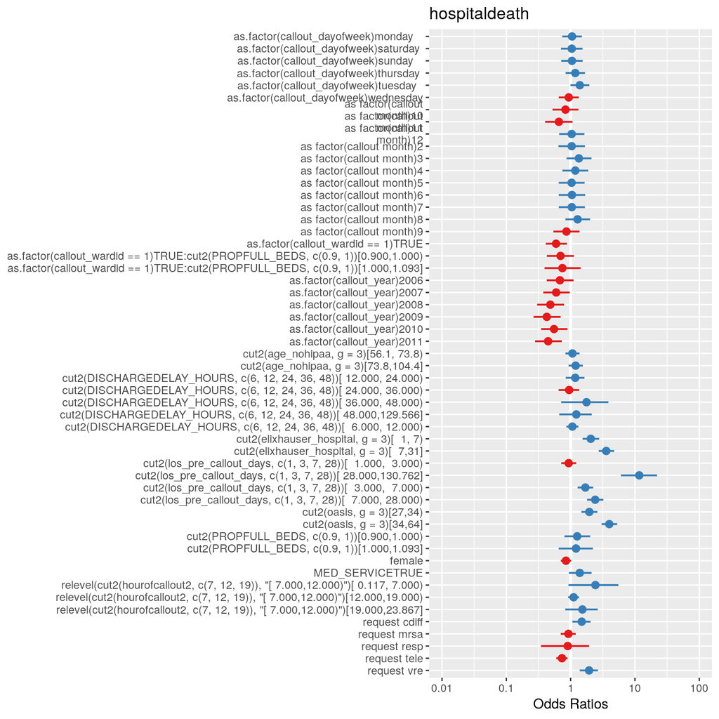

|  |  | hospitaldeath |  |  |
| --- | --- | --- | --- | --- |
|  |  | Odds Ratio | CI | p |
| (Intercept) |  | 0.02 | 0.01 – 0.04 | <.001 |
| cut2(DISCHARGEDELAY_HOURS, c(6, 12, 24, 36, 48)) |  |  |  |  |
| cut2(DISCHARGEDELAY_HOURS, c(6, 12, 24, 36, 48))[ 6.000, 12.000) |  | 1.06 | 0.86 – 1.32 | .576 |
| cut2(DISCHARGEDELAY_HOURS, c(6, 12, 24, 36, 48))[ 12.000, 24.000) |  | 1.18 | 0.84 – 1.64 | .331 |
| cut2(DISCHARGEDELAY_HOURS, c(6, 12, 24, 36, 48))[ 24.000, 36.000) |  | 0.95 | 0.65 – 1.36 | .777 |
| cut2(DISCHARGEDELAY_HOURS, c(6, 12, 24, 36, 48))[ 36.000, 48.000) |  | 1.76 | 0.71 – 3.86 | .183 |
| cut2(DISCHARGEDELAY_HOURS, c(6, 12, 24, 36, 48))[ 48.000,129.566] |  | 1.22 | 0.66 – 2.13 | .493 |
| cut2(oasis, g = 3) |  |  |  |  |
| cut2(oasis, g = 3)[27,34) |  | 1.95 | 1.47 – 2.61 | <.001 |
| cut2(oasis, g = 3)[34,64] |  | 3.98 | 3.03 – 5.30 | <.001 |
| cut2(age_nohipaa, g = 3) |  |  |  |  |
| cut2(age_nohipaa, g = 3)[56.1, 73.8) |  | 1.07 | 0.83 – 1.37 | .614 |
| cut2(age_nohipaa, g = 3)[73.8,104.4] |  | 1.20 | 0.93 – 1.55 | .167 |
| female |  | 0.85 | 0.70 – 1.02 | .079 |
| request_tele |  | 0.73 | 0.60 – 0.89 | .002 |
| request_resp |  | 0.90 | 0.35 – 1.93 | .810 |
| request_mrsa |  | 0.92 | 0.70 – 1.20 | .563 |
| request_vre |  | 1.93 | 1.39 – 2.66 | <.001 |
| request_cdiff |  | 1.49 | 1.07 – 2.04 | .016 |
| cut2(elixhauser_hospital, g = 3) |  |  |  |  |
| cut2(elixhauser_hospital, g = 3)[ 1, 7) |  | 2.05 | 1.53 – 2.78 | <.001 |
| cut2(elixhauser_hospital, g = 3)[ 7,31] |  | 3.57 | 2.73 – 4.74 | <.001 |
| cut2(los_pre_callout_days, c(1, 3, 7, 28)) |  |  |  |  |
| cut2(los_pre_callout_days, c(1, 3, 7, 28))[ 1.000, 3.000) |  | 0.93 | 0.71 – 1.22 | .606 |
| cut2(los_pre_callout_days, c(1, 3, 7, 28))[ 3.000, 7.000) |  | 1.69 | 1.28 – 2.24 | <.001 |
| cut2(los_pre_callout_days, c(1, 3, 7, 28))[ 7.000, 28.000) |  | 2.41 | 1.80 – 3.23 | <.001 |
| cut2(los_pre_callout_days, c(1, 3, 7, 28))[ 28.000,130.762] |  | 11.66 | 6.05 – 22.10 | <.001 |
| as.factor(callout_month) |  |  |  |  |
| as.factor(callout_month)2 |  | 1.04 | 0.65 – 1.67 | .876 |
| as.factor(callout_month)3 |  | 1.34 | 0.86 – 2.11 | .194 |
| as.factor(callout_month)4 |  | 1.18 | 0.74 – 1.88 | .479 |
| as.factor(callout_month)5 |  | 1.04 | 0.65 – 1.65 | .883 |
| as.factor(callout_month)6 |  | 1.05 | 0.65 – 1.68 | .844 |
| as.factor(callout_month)7 |  | 1.04 | 0.65 – 1.67 | .861 |
| as.factor(callout_month)8 |  | 1.28 | 0.83 – 2.00 | .269 |
| as.factor(callout_month)9 |  | 0.86 | 0.54 – 1.37 | .527 |
| as.factor(callout_month)10 |  | 0.83 | 0.52 – 1.33 | .437 |
| as.factor(callout_month)11 |  | 0.66 | 0.40 – 1.07 | .092 |
| as.factor(callout_month)12 |  | 1.04 | 0.66 – 1.64 | .872 |
| as.factor(callout_year) |  |  |  |  |
| as.factor(callout_year)2006 |  | 0.68 | 0.42 – 1.11 | .117 |
| as.factor(callout_year)2007 |  | 0.60 | 0.38 – 0.97 | .032 |
| as.factor(callout_year)2008 |  | 0.48 | 0.30 – 0.79 | .003 |
| as.factor(callout_year)2009 |  | 0.43 | 0.26 – 0.70 | <.001 |
| as.factor(callout_year)2010 |  | 0.55 | 0.35 – 0.89 | .013 |
| as.factor(callout_year)2011 |  | 0.45 | 0.28 – 0.73 | <.001 |
| as.factor(callout_dayofweek) |  |  |  |  |
| as.factor(callout_dayofweek)monday |  | 1.05 | 0.74 – 1.49 | .781 |
| as.factor(callout_dayofweek)saturday |  | 1.04 | 0.71 – 1.53 | .839 |
| as.factor(callout_dayofweek)sunday |  | 1.05 | 0.71 – 1.54 | .812 |
| as.factor(callout_dayofweek)thursday |  | 1.18 | 0.84 – 1.67 | .347 |
| as.factor(callout_dayofweek)tuesday |  | 1.39 | 0.99 – 1.95 | .056 |
| as.factor(callout_dayofweek)wednesday |  | 0.93 | 0.65 – 1.34 | .713 |
| as.factor(callout_wardid == 1)TRUE |  | 0.59 | 0.41 – 0.87 | .007 |
| cut2(PROPFULL_BEDS, c(0.9, 1)) |  |  |  |  |
| cut2(PROPFULL_BEDS, c(0.9, 1))[0.900,1.000) |  | 1.26 | 0.80 – 2.01 | .319 |
| cut2(PROPFULL_BEDS, c(0.9, 1))[1.000,1.093] |  | 1.21 | 0.65 – 2.22 | .538 |
| MED_SERVICETRUE |  | 1.39 | 0.94 – 2.12 | .113 |
| relevel(cut2(hourofcallout2, c(7, 12, 19)), “[ 7.000,12.000)”) |  |  |  |  |
| relevel(cut2(hourofcallout2, c(7, 12, 19)), “[ 7.000,12.000)”)[ 0.117, 7.000) |  | 2.43 | 0.93 – 5.51 | .049 |
| relevel(cut2(hourofcallout2, c(7, 12, 19)), “[ 7.000,12.000)”)[12.000,19.000) |  | 1.11 | 0.91 – 1.35 | .287 |
| relevel(cut2(hourofcallout2, c(7, 12, 19)), “[ 7.000,12.000)”)[19.000,23.867] |  | 1.52 | 0.83 – 2.63 | .152 |
| as.factor(callout_wardid == 1)TRUE:cut2(PROPFULL_BEDS, c(0.9, 1))[0.900,1.000) |  | 0.70 | 0.43 – 1.13 | .145 |
| as.factor(callout_wardid == 1)TRUE:cut2(PROPFULL_BEDS, c(0.9, 1))[1.000,1.093] |  | 0.74 | 0.39 – 1.43 | .371 |
| Observations |  | 9673 |  |  |

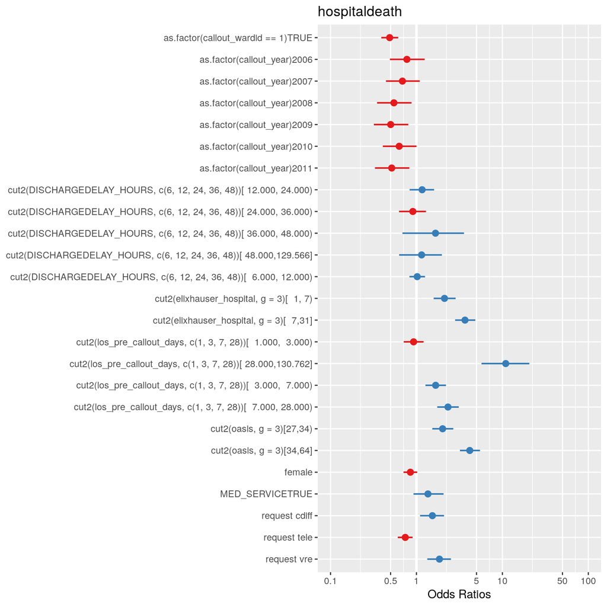

|  |  | hospitaldeath |  |  |
| --- | --- | --- | --- | --- |
|  |  | Odds Ratio | CI | p |
| (Intercept) |  | 0.02 | 0.01 – 0.04 | <.001 |
| cut2(DISCHARGEDELAY_HOURS, c(6, 12, 24, 36, 48)) |  |  |  |  |
| [ 6.000, 12.000) |  | 1.02 | 0.83 – 1.26 | .849 |
| [ 12.000, 24.000) |  | 1.16 | 0.83 – 1.60 | .364 |
| [ 24.000, 36.000) |  | 0.91 | 0.63 – 1.29 | .596 |
| [ 36.000, 48.000) |  | 1.66 | 0.69 – 3.57 | .220 |
| [ 48.000,129.566] |  | 1.15 | 0.63 – 1.98 | .634 |
| cut2(oasis, g = 3) |  |  |  |  |
| [27,34) |  | 2.02 | 1.53 – 2.68 | <.001 |
| [34,64] |  | 4.17 | 3.21 – 5.49 | <.001 |
| female |  | 0.85 | 0.71 – 1.02 | .083 |
| request_tele |  | 0.74 | 0.61 – 0.90 | .003 |
| request_vre |  | 1.85 | 1.34 – 2.52 | <.001 |
| request_cdiff |  | 1.53 | 1.10 – 2.09 | .009 |
| cut2(elixhauser_hospital, g = 3) |  |  |  |  |
| [ 1, 7) |  | 2.12 | 1.59 – 2.86 | <.001 |
| [ 7,31] |  | 3.67 | 2.82 – 4.84 | <.001 |
| cut2(los_pre_callout_days, c(1, 3, 7, 28)) |  |  |  |  |
| [ 1.000, 3.000) |  | 0.93 | 0.71 – 1.21 | .569 |
| [ 3.000, 7.000) |  | 1.67 | 1.27 – 2.21 | <.001 |
| [ 7.000, 28.000) |  | 2.33 | 1.75 – 3.11 | <.001 |
| [ 28.000,130.762] |  | 10.93 | 5.71 – 20.58 | <.001 |
| as.factor(callout_year) |  |  |  |  |
| 2006 |  | 0.77 | 0.49 – 1.25 | .279 |
| 2007 |  | 0.69 | 0.44 – 1.09 | .103 |
| 2008 |  | 0.55 | 0.35 – 0.88 | .010 |
| 2009 |  | 0.50 | 0.32 – 0.80 | .003 |
| 2010 |  | 0.63 | 0.41 – 1.00 | .043 |
| 2011 |  | 0.52 | 0.33 – 0.83 | .005 |
| as.factor(callout_wardid == 1) (TRUE) |  | 0.49 | 0.39 – 0.61 | <.001 |
| MED_SERVICE |  | 1.36 | 0.92 – 2.07 | .134 |
| Observations |  | 9673 |  |  |

```
## Single term deletions
##
## Model:
## hospitaldeath ~ cut2(DISCHARGEDELAY_HOURS, c(6, 12, 24, 36, 48)) +
##     cut2(oasis, g = 3) + female + request_tele + request_vre +
##     request_cdiff + cut2(elixhauser_hospital, g = 3) + cut2(los_pre_callout_days,
##     c(1, 3, 7, 28)) + as.factor(callout_year) + as.factor(callout_wardid ==
##     1) + MED_SERVICE
##                                                  Df Deviance    AIC
## <none>                                                3578.2 3630.2
## cut2(DISCHARGEDELAY_HOURS, c(6, 12, 24, 36, 48))  5   3581.1 3623.1
## cut2(oasis, g = 3)                                2   3712.5 3760.5
## female                                            1   3581.2 3631.2
## request_tele                                      1   3587.2 3637.2
## request_vre                                       1   3591.3 3641.3
## request_cdiff                                     1   3584.5 3634.5
## cut2(elixhauser_hospital, g = 3)                  2   3686.6 3734.6
## cut2(los_pre_callout_days, c(1, 3, 7, 28))        4   3676.2 3720.2
## as.factor(callout_year)                           6   3592.9 3632.9
## as.factor(callout_wardid == 1)                    1   3613.5 3663.5
## MED_SERVICE                                       1   3580.6 3630.6
##                                                      LRT  Pr(>Chi)
## <none>
## cut2(DISCHARGEDELAY_HOURS, c(6, 12, 24, 36, 48))   2.866  0.720626
## cut2(oasis, g = 3)                               134.312 < 2.2e-16 ***
## female                                             3.017  0.082381 .
## request_tele                                       8.952  0.002772 **
## request_vre                                       13.033  0.000306 ***
## request_cdiff                                      6.310  0.012004 *
## cut2(elixhauser_hospital, g = 3)                 108.394 < 2.2e-16 ***
## cut2(los_pre_callout_days, c(1, 3, 7, 28))        97.927 < 2.2e-16 ***
## as.factor(callout_year)                           14.684  0.022862 *
## as.factor(callout_wardid == 1)                    35.300 2.827e-09 ***
## MED_SERVICE                                        2.389  0.122164
## ---
## Signif. codes:  0 '***' 0.001 '**' 0.01 '*' 0.05 '.' 0.1 ' ' 1
```

```
## Single term deletions
##
## Model:
## hospitaldeath ~ cut2(DISCHARGEDELAY_HOURS, c(6, 12, 24, 36, 48)) +
##     cut2(oasis, g = 3) + cut2(age_nohipaa, g = 3) + female +
##     request_tele + request_resp + request_mrsa + request_vre +
##     request_cdiff + cut2(elixhauser_hospital, g = 3) + cut2(los_pre_callout_days,
##     c(1, 3, 7, 28)) + as.factor(callout_month) + as.factor(callout_year) +
##     as.factor(callout_dayofweek) + as.factor(callout_wardid ==
##     1) * cut2(PROPFULL_BEDS, c(0.9, 1)) + MED_SERVICE + relevel(cut2(hourofcallout2,
##     c(7, 12, 19)), "[ 7.000,12.000)")
##                                                                Df Deviance
## <none>                                                              3545.3
## cut2(oasis, g = 3)                                              2   3658.4
## cut2(age_nohipaa, g = 3)                                        2   3547.4
## female                                                          1   3548.4
## request_tele                                                    1   3554.8
## request_resp                                                    1   3545.4
## request_mrsa                                                    1   3545.7
## request_vre                                                     1   3559.5
## request_cdiff                                                   1   3550.7
## cut2(elixhauser_hospital, g = 3)                                2   3645.6
## cut2(los_pre_callout_days, c(1, 3, 7, 28))                      4   3645.9
## as.factor(callout_month)                                       11   3560.7
## as.factor(callout_year)                                         6   3562.9
## as.factor(callout_dayofweek)                                    6   3552.3
## MED_SERVICE                                                     1   3548.0
## relevel(cut2(hourofcallout2, c(7, 12, 19)), "[ 7.000,12.000)")  3   3550.9
## as.factor(callout_wardid == 1):cut2(PROPFULL_BEDS, c(0.9, 1))   2   3547.6
##                                                                   AIC
## <none>                                                         3653.3
## cut2(oasis, g = 3)                                             3762.4
## cut2(age_nohipaa, g = 3)                                       3651.4
## female                                                         3654.4
## request_tele                                                   3660.8
## request_resp                                                   3651.4
## request_mrsa                                                   3651.7
## request_vre                                                    3665.5
## request_cdiff                                                  3656.7
## cut2(elixhauser_hospital, g = 3)                               3749.6
```

[output cut: 48 more lines]

```
## request_tele                                                   **
## request_resp
## request_mrsa
## request_vre                                                    ***
## request_cdiff                                                  *
## cut2(elixhauser_hospital, g = 3)                               ***
## cut2(los_pre_callout_days, c(1, 3, 7, 28))                     ***
## as.factor(callout_month)
## as.factor(callout_year)                                        **
## as.factor(callout_dayofweek)
## MED_SERVICE
## relevel(cut2(hourofcallout2, c(7, 12, 19)), "[ 7.000,12.000)")
## as.factor(callout_wardid == 1):cut2(PROPFULL_BEDS, c(0.9, 1))
## ---
## Signif. codes:  0 '***' 0.001 '**' 0.01 '*' 0.05 '.' 0.1 ' ' 1
```

```
## [1] "request_resp"
```

```
## [1] 0.8071423
```

```
##
## Call:  glm(formula = hospitaldeath ~ cut2(DISCHARGEDELAY_HOURS, c(6,
##     12, 24, 36, 48)) + cut2(oasis, g = 3) + cut2(age_nohipaa,
##     g = 3) + female + request_tele + request_mrsa + request_vre +
##     request_cdiff + cut2(elixhauser_hospital, g = 3) + cut2(los_pre_callout_days,
##     c(1, 3, 7, 28)) + as.factor(callout_month) + as.factor(callout_year) +
##     as.factor(callout_dayofweek) + as.factor(callout_wardid ==
##     1) + cut2(PROPFULL_BEDS, c(0.9, 1)) + MED_SERVICE + relevel(cut2(hourofcallout2,
##     c(7, 12, 19)), "[ 7.000,12.000)") + as.factor(callout_wardid ==
##     1):cut2(PROPFULL_BEDS, c(0.9, 1)), family = "binomial", data = d)
##
## Coefficients:
##                                                                    (Intercept)
##                                                                       -4.12916
##              cut2(DISCHARGEDELAY_HOURS, c(6, 12, 24, 36, 48))[  6.000, 12.000)
##                                                                        0.06180
##              cut2(DISCHARGEDELAY_HOURS, c(6, 12, 24, 36, 48))[ 12.000, 24.000)
##                                                                        0.16545
##              cut2(DISCHARGEDELAY_HOURS, c(6, 12, 24, 36, 48))[ 24.000, 36.000)
##                                                                       -0.05275
##              cut2(DISCHARGEDELAY_HOURS, c(6, 12, 24, 36, 48))[ 36.000, 48.000)
##                                                                        0.56846
##              cut2(DISCHARGEDELAY_HOURS, c(6, 12, 24, 36, 48))[ 48.000,129.566]
##                                                                        0.20223
##                                                      cut2(oasis, g = 3)[27,34)
##                                                                        0.66885
##                                                      cut2(oasis, g = 3)[34,64]
##                                                                        1.38236
##                                           cut2(age_nohipaa, g = 3)[56.1, 73.8)
##                                                                        0.06479
##                                           cut2(age_nohipaa, g = 3)[73.8,104.4]
##                                                                        0.18005
##                                                                         female
##                                                                       -0.16596
##                                                                   request_tele
##                                                                       -0.31132
##                                                                   request_mrsa
##                                                                       -0.07980
##                                                                    request_vre
##                                                                        0.66040
```

[output cut: 67 more lines]

```
##                                                                        0.32699
##  relevel(cut2(hourofcallout2, c(7, 12, 19)), "[ 7.000,12.000)")[ 0.117, 7.000)
##                                                                        0.88881
##  relevel(cut2(hourofcallout2, c(7, 12, 19)), "[ 7.000,12.000)")[12.000,19.000)
##                                                                        0.10696
##  relevel(cut2(hourofcallout2, c(7, 12, 19)), "[ 7.000,12.000)")[19.000,23.867]
##                                                                        0.42292
## as.factor(callout_wardid == 1)TRUE:cut2(PROPFULL_BEDS, c(0.9, 1))[0.900,1.000)
##                                                                       -0.36365
## as.factor(callout_wardid == 1)TRUE:cut2(PROPFULL_BEDS, c(0.9, 1))[1.000,1.093]
##                                                                       -0.29617
##
## Degrees of Freedom: 9672 Total (i.e. Null);  9620 Residual
## Null Deviance:       4126
## Residual Deviance: 3545  AIC: 3651
```

```
## [1] "request_mrsa"
```

```
## [1] 0.5573796
```

```
##
## Call:  glm(formula = hospitaldeath ~ cut2(DISCHARGEDELAY_HOURS, c(6,
##     12, 24, 36, 48)) + cut2(oasis, g = 3) + cut2(age_nohipaa,
##     g = 3) + female + request_tele + request_vre + request_cdiff +
##     cut2(elixhauser_hospital, g = 3) + cut2(los_pre_callout_days,
##     c(1, 3, 7, 28)) + as.factor(callout_month) + as.factor(callout_year) +
##     as.factor(callout_dayofweek) + as.factor(callout_wardid ==
##     1) + cut2(PROPFULL_BEDS, c(0.9, 1)) + MED_SERVICE + relevel(cut2(hourofcallout2,
##     c(7, 12, 19)), "[ 7.000,12.000)") + as.factor(callout_wardid ==
##     1):cut2(PROPFULL_BEDS, c(0.9, 1)), family = "binomial", data = d)
##
## Coefficients:
##                                                                    (Intercept)
##                                                                       -4.12747
##              cut2(DISCHARGEDELAY_HOURS, c(6, 12, 24, 36, 48))[  6.000, 12.000)
##                                                                        0.06056
##              cut2(DISCHARGEDELAY_HOURS, c(6, 12, 24, 36, 48))[ 12.000, 24.000)
##                                                                        0.16424
##              cut2(DISCHARGEDELAY_HOURS, c(6, 12, 24, 36, 48))[ 24.000, 36.000)
##                                                                       -0.05624
##              cut2(DISCHARGEDELAY_HOURS, c(6, 12, 24, 36, 48))[ 36.000, 48.000)
##                                                                        0.56087
##              cut2(DISCHARGEDELAY_HOURS, c(6, 12, 24, 36, 48))[ 48.000,129.566]
##                                                                        0.19280
##                                                      cut2(oasis, g = 3)[27,34)
##                                                                        0.66919
##                                                      cut2(oasis, g = 3)[34,64]
##                                                                        1.38163
##                                           cut2(age_nohipaa, g = 3)[56.1, 73.8)
##                                                                        0.06156
##                                           cut2(age_nohipaa, g = 3)[73.8,104.4]
##                                                                        0.17697
##                                                                         female
##                                                                       -0.16570
##                                                                   request_tele
##                                                                       -0.31170
##                                                                    request_vre
##                                                                        0.64323
##                                                                  request_cdiff
##                                                                        0.39940
```

[output cut: 65 more lines]

```
##                                                                        0.32236
##  relevel(cut2(hourofcallout2, c(7, 12, 19)), "[ 7.000,12.000)")[ 0.117, 7.000)
##                                                                        0.88859
##  relevel(cut2(hourofcallout2, c(7, 12, 19)), "[ 7.000,12.000)")[12.000,19.000)
##                                                                        0.10742
##  relevel(cut2(hourofcallout2, c(7, 12, 19)), "[ 7.000,12.000)")[19.000,23.867]
##                                                                        0.42444
## as.factor(callout_wardid == 1)TRUE:cut2(PROPFULL_BEDS, c(0.9, 1))[0.900,1.000)
##                                                                       -0.36280
## as.factor(callout_wardid == 1)TRUE:cut2(PROPFULL_BEDS, c(0.9, 1))[1.000,1.093]
##                                                                       -0.29582
##
## Degrees of Freedom: 9672 Total (i.e. Null);  9621 Residual
## Null Deviance:       4126
## Residual Deviance: 3546  AIC: 3650
```

```
## [1] "cut2(age_nohipaa, g = 3)"
```

```
## [1] 0.3528542
```

```
##
## Call:  glm(formula = hospitaldeath ~ cut2(DISCHARGEDELAY_HOURS, c(6,
##     12, 24, 36, 48)) + cut2(oasis, g = 3) + female + request_tele +
##     request_vre + request_cdiff + cut2(elixhauser_hospital, g = 3) +
##     cut2(los_pre_callout_days, c(1, 3, 7, 28)) + as.factor(callout_month) +
##     as.factor(callout_year) + as.factor(callout_dayofweek) +
##     as.factor(callout_wardid == 1) + cut2(PROPFULL_BEDS, c(0.9,
##     1)) + MED_SERVICE + relevel(cut2(hourofcallout2, c(7, 12,
##     19)), "[ 7.000,12.000)") + as.factor(callout_wardid == 1):cut2(PROPFULL_BEDS,
##     c(0.9, 1)), family = "binomial", data = d)
##
## Coefficients:
##                                                                    (Intercept)
##                                                                       -4.09571
##              cut2(DISCHARGEDELAY_HOURS, c(6, 12, 24, 36, 48))[  6.000, 12.000)
##                                                                        0.06019
##              cut2(DISCHARGEDELAY_HOURS, c(6, 12, 24, 36, 48))[ 12.000, 24.000)
##                                                                        0.16270
##              cut2(DISCHARGEDELAY_HOURS, c(6, 12, 24, 36, 48))[ 24.000, 36.000)
##                                                                       -0.06139
##              cut2(DISCHARGEDELAY_HOURS, c(6, 12, 24, 36, 48))[ 36.000, 48.000)
##                                                                        0.54813
##              cut2(DISCHARGEDELAY_HOURS, c(6, 12, 24, 36, 48))[ 48.000,129.566]
##                                                                        0.19014
##                                                      cut2(oasis, g = 3)[27,34)
##                                                                        0.69507
##                                                      cut2(oasis, g = 3)[34,64]
##                                                                        1.43611
##                                                                         female
##                                                                       -0.15869
##                                                                   request_tele
##                                                                       -0.30025
##                                                                    request_vre
##                                                                        0.63476
##                                                                  request_cdiff
##                                                                        0.41213
##                                       cut2(elixhauser_hospital, g = 3)[  1, 7)
##                                                                        0.73831
##                                       cut2(elixhauser_hospital, g = 3)[  7,31]
##                                                                        1.30424
```

[output cut: 61 more lines]

```
##                                                                        0.30727
##  relevel(cut2(hourofcallout2, c(7, 12, 19)), "[ 7.000,12.000)")[ 0.117, 7.000)
##                                                                        0.87296
##  relevel(cut2(hourofcallout2, c(7, 12, 19)), "[ 7.000,12.000)")[12.000,19.000)
##                                                                        0.11000
##  relevel(cut2(hourofcallout2, c(7, 12, 19)), "[ 7.000,12.000)")[19.000,23.867]
##                                                                        0.41803
## as.factor(callout_wardid == 1)TRUE:cut2(PROPFULL_BEDS, c(0.9, 1))[0.900,1.000)
##                                                                       -0.35573
## as.factor(callout_wardid == 1)TRUE:cut2(PROPFULL_BEDS, c(0.9, 1))[1.000,1.093]
##                                                                       -0.29318
##
## Degrees of Freedom: 9672 Total (i.e. Null);  9623 Residual
## Null Deviance:       4126
## Residual Deviance: 3548  AIC: 3648
```

```
## [1] "as.factor(callout_wardid == 1):cut2(PROPFULL_BEDS, c(0.9, 1))"
```

```
## [1] 0.3381121
```

```
##
## Call:  glm(formula = hospitaldeath ~ cut2(DISCHARGEDELAY_HOURS, c(6,
##     12, 24, 36, 48)) + cut2(oasis, g = 3) + female + request_tele +
##     request_vre + request_cdiff + cut2(elixhauser_hospital, g = 3) +
##     cut2(los_pre_callout_days, c(1, 3, 7, 28)) + as.factor(callout_month) +
##     as.factor(callout_year) + as.factor(callout_dayofweek) +
##     as.factor(callout_wardid == 1) + cut2(PROPFULL_BEDS, c(0.9,
##     1)) + MED_SERVICE + relevel(cut2(hourofcallout2, c(7, 12,
##     19)), "[ 7.000,12.000)"), family = "binomial", data = d)
##
## Coefficients:
##                                                                   (Intercept)
##                                                                      -3.92391
##             cut2(DISCHARGEDELAY_HOURS, c(6, 12, 24, 36, 48))[  6.000, 12.000)
##                                                                       0.05831
##             cut2(DISCHARGEDELAY_HOURS, c(6, 12, 24, 36, 48))[ 12.000, 24.000)
##                                                                       0.15292
##             cut2(DISCHARGEDELAY_HOURS, c(6, 12, 24, 36, 48))[ 24.000, 36.000)
##                                                                      -0.06719
##             cut2(DISCHARGEDELAY_HOURS, c(6, 12, 24, 36, 48))[ 36.000, 48.000)
##                                                                       0.52822
##             cut2(DISCHARGEDELAY_HOURS, c(6, 12, 24, 36, 48))[ 48.000,129.566]
##                                                                       0.18867
##                                                     cut2(oasis, g = 3)[27,34)
##                                                                       0.69187
##                                                     cut2(oasis, g = 3)[34,64]
##                                                                       1.43273
##                                                                        female
##                                                                      -0.15529
##                                                                  request_tele
##                                                                      -0.30146
##                                                                   request_vre
##                                                                       0.63378
##                                                                 request_cdiff
##                                                                       0.42145
##                                      cut2(elixhauser_hospital, g = 3)[  1, 7)
##                                                                       0.74021
##                                      cut2(elixhauser_hospital, g = 3)[  7,31]
##                                                                       1.30859
##                   cut2(los_pre_callout_days, c(1, 3, 7, 28))[  1.000,  3.000)
```

[output cut: 56 more lines]

```
##                                                                      -0.04262
##                                   cut2(PROPFULL_BEDS, c(0.9, 1))[1.000,1.093]
##                                                                      -0.03129
##                                                               MED_SERVICETRUE
##                                                                       0.30360
## relevel(cut2(hourofcallout2, c(7, 12, 19)), "[ 7.000,12.000)")[ 0.117, 7.000)
##                                                                       0.85583
## relevel(cut2(hourofcallout2, c(7, 12, 19)), "[ 7.000,12.000)")[12.000,19.000)
##                                                                       0.10785
## relevel(cut2(hourofcallout2, c(7, 12, 19)), "[ 7.000,12.000)")[19.000,23.867]
##                                                                       0.39523
##
## Degrees of Freedom: 9672 Total (i.e. Null);  9625 Residual
## Null Deviance:       4126
## Residual Deviance: 3550  AIC: 3646
```

```
## [1] "cut2(PROPFULL_BEDS, c(0.9, 1))"
```

```
## [1] 0.9521229
```

```
##
## Call:  glm(formula = hospitaldeath ~ cut2(DISCHARGEDELAY_HOURS, c(6,
##     12, 24, 36, 48)) + cut2(oasis, g = 3) + female + request_tele +
##     request_vre + request_cdiff + cut2(elixhauser_hospital, g = 3) +
##     cut2(los_pre_callout_days, c(1, 3, 7, 28)) + as.factor(callout_month) +
##     as.factor(callout_year) + as.factor(callout_dayofweek) +
##     as.factor(callout_wardid == 1) + MED_SERVICE + relevel(cut2(hourofcallout2,
##     c(7, 12, 19)), "[ 7.000,12.000)"), family = "binomial", data = d)
##
## Coefficients:
##                                                                   (Intercept)
##                                                                      -3.94893
##             cut2(DISCHARGEDELAY_HOURS, c(6, 12, 24, 36, 48))[  6.000, 12.000)
##                                                                       0.05628
##             cut2(DISCHARGEDELAY_HOURS, c(6, 12, 24, 36, 48))[ 12.000, 24.000)
##                                                                       0.14886
##             cut2(DISCHARGEDELAY_HOURS, c(6, 12, 24, 36, 48))[ 24.000, 36.000)
##                                                                      -0.07187
##             cut2(DISCHARGEDELAY_HOURS, c(6, 12, 24, 36, 48))[ 36.000, 48.000)
##                                                                       0.52316
##             cut2(DISCHARGEDELAY_HOURS, c(6, 12, 24, 36, 48))[ 48.000,129.566]
##                                                                       0.18233
##                                                     cut2(oasis, g = 3)[27,34)
##                                                                       0.69256
##                                                     cut2(oasis, g = 3)[34,64]
##                                                                       1.43329
##                                                                        female
##                                                                      -0.15585
##                                                                  request_tele
##                                                                      -0.30267
##                                                                   request_vre
##                                                                       0.63485
##                                                                 request_cdiff
##                                                                       0.42224
##                                      cut2(elixhauser_hospital, g = 3)[  1, 7)
##                                                                       0.74054
##                                      cut2(elixhauser_hospital, g = 3)[  7,31]
##                                                                       1.30875
##                   cut2(los_pre_callout_days, c(1, 3, 7, 28))[  1.000,  3.000)
##                                                                      -0.07708
```

[output cut: 51 more lines]

```
##                                                                      -0.06793
##                                            as.factor(callout_wardid == 1)TRUE
##                                                                      -0.72198
##                                                               MED_SERVICETRUE
##                                                                       0.30371
## relevel(cut2(hourofcallout2, c(7, 12, 19)), "[ 7.000,12.000)")[ 0.117, 7.000)
##                                                                       0.85777
## relevel(cut2(hourofcallout2, c(7, 12, 19)), "[ 7.000,12.000)")[12.000,19.000)
##                                                                       0.10781
## relevel(cut2(hourofcallout2, c(7, 12, 19)), "[ 7.000,12.000)")[19.000,23.867]
##                                                                       0.39884
##
## Degrees of Freedom: 9672 Total (i.e. Null);  9627 Residual
## Null Deviance:       4126
## Residual Deviance: 3550  AIC: 3642
```

```
## [1] "as.factor(callout_dayofweek)"
```

```
## [1] 0.331835
```

```
##
## Call:  glm(formula = hospitaldeath ~ cut2(DISCHARGEDELAY_HOURS, c(6,
##     12, 24, 36, 48)) + cut2(oasis, g = 3) + female + request_tele +
##     request_vre + request_cdiff + cut2(elixhauser_hospital, g = 3) +
##     cut2(los_pre_callout_days, c(1, 3, 7, 28)) + as.factor(callout_month) +
##     as.factor(callout_year) + as.factor(callout_wardid == 1) +
##     MED_SERVICE + relevel(cut2(hourofcallout2, c(7, 12, 19)),
##     "[ 7.000,12.000)"), family = "binomial", data = d)
##
## Coefficients:
##                                                                   (Intercept)
##                                                                      -3.85723
##             cut2(DISCHARGEDELAY_HOURS, c(6, 12, 24, 36, 48))[  6.000, 12.000)
##                                                                       0.06126
##             cut2(DISCHARGEDELAY_HOURS, c(6, 12, 24, 36, 48))[ 12.000, 24.000)
##                                                                       0.15024
##             cut2(DISCHARGEDELAY_HOURS, c(6, 12, 24, 36, 48))[ 24.000, 36.000)
##                                                                      -0.06438
##             cut2(DISCHARGEDELAY_HOURS, c(6, 12, 24, 36, 48))[ 36.000, 48.000)
##                                                                       0.51991
##             cut2(DISCHARGEDELAY_HOURS, c(6, 12, 24, 36, 48))[ 48.000,129.566]
##                                                                       0.20138
##                                                     cut2(oasis, g = 3)[27,34)
##                                                                       0.69657
##                                                     cut2(oasis, g = 3)[34,64]
##                                                                       1.43271
##                                                                        female
##                                                                      -0.15686
##                                                                  request_tele
##                                                                      -0.30017
##                                                                   request_vre
##                                                                       0.63213
##                                                                 request_cdiff
##                                                                       0.42322
##                                      cut2(elixhauser_hospital, g = 3)[  1, 7)
##                                                                       0.74430
##                                      cut2(elixhauser_hospital, g = 3)[  7,31]
##                                                                       1.30687
##                   cut2(los_pre_callout_days, c(1, 3, 7, 28))[  1.000,  3.000)
##                                                                      -0.08177
```

[output cut: 39 more lines]

```
##                                                                      -0.80666
##                                            as.factor(callout_wardid == 1)TRUE
##                                                                      -0.71640
##                                                               MED_SERVICETRUE
##                                                                       0.29105
## relevel(cut2(hourofcallout2, c(7, 12, 19)), "[ 7.000,12.000)")[ 0.117, 7.000)
##                                                                       0.87169
## relevel(cut2(hourofcallout2, c(7, 12, 19)), "[ 7.000,12.000)")[12.000,19.000)
##                                                                       0.10614
## relevel(cut2(hourofcallout2, c(7, 12, 19)), "[ 7.000,12.000)")[19.000,23.867]
##                                                                       0.41435
##
## Degrees of Freedom: 9672 Total (i.e. Null);  9633 Residual
## Null Deviance:       4126
## Residual Deviance: 3557  AIC: 3637
```

```
## [1] "as.factor(callout_month)"
```

```
## [1] 0.1620413
```

```
##
## Call:  glm(formula = hospitaldeath ~ cut2(DISCHARGEDELAY_HOURS, c(6,
##     12, 24, 36, 48)) + cut2(oasis, g = 3) + female + request_tele +
##     request_vre + request_cdiff + cut2(elixhauser_hospital, g = 3) +
##     cut2(los_pre_callout_days, c(1, 3, 7, 28)) + as.factor(callout_year) +
##     as.factor(callout_wardid == 1) + MED_SERVICE + relevel(cut2(hourofcallout2,
##     c(7, 12, 19)), "[ 7.000,12.000)"), family = "binomial", data = d)
##
## Coefficients:
##                                                                   (Intercept)
##                                                                      -3.93805
##             cut2(DISCHARGEDELAY_HOURS, c(6, 12, 24, 36, 48))[  6.000, 12.000)
##                                                                       0.05567
##             cut2(DISCHARGEDELAY_HOURS, c(6, 12, 24, 36, 48))[ 12.000, 24.000)
##                                                                       0.14572
##             cut2(DISCHARGEDELAY_HOURS, c(6, 12, 24, 36, 48))[ 24.000, 36.000)
##                                                                      -0.08734
##             cut2(DISCHARGEDELAY_HOURS, c(6, 12, 24, 36, 48))[ 36.000, 48.000)
##                                                                       0.50015
##             cut2(DISCHARGEDELAY_HOURS, c(6, 12, 24, 36, 48))[ 48.000,129.566]
##                                                                       0.14728
##                                                     cut2(oasis, g = 3)[27,34)
##                                                                       0.69830
##                                                     cut2(oasis, g = 3)[34,64]
##                                                                       1.42388
##                                                                        female
##                                                                      -0.16017
##                                                                  request_tele
##                                                                      -0.30266
##                                                                   request_vre
##                                                                       0.61050
##                                                                 request_cdiff
##                                                                       0.43433
##                                      cut2(elixhauser_hospital, g = 3)[  1, 7)
##                                                                       0.74611
##                                      cut2(elixhauser_hospital, g = 3)[  7,31]
##                                                                       1.30031
##                   cut2(los_pre_callout_days, c(1, 3, 7, 28))[  1.000,  3.000)
##                                                                      -0.08606
##                   cut2(los_pre_callout_days, c(1, 3, 7, 28))[  3.000,  7.000)
```

[output cut: 16 more lines]

```
##                                                                      -0.67570
##                                            as.factor(callout_wardid == 1)TRUE
##                                                                      -0.72316
##                                                               MED_SERVICETRUE
##                                                                       0.30486
## relevel(cut2(hourofcallout2, c(7, 12, 19)), "[ 7.000,12.000)")[ 0.117, 7.000)
##                                                                       0.90765
## relevel(cut2(hourofcallout2, c(7, 12, 19)), "[ 7.000,12.000)")[12.000,19.000)
##                                                                       0.10090
## relevel(cut2(hourofcallout2, c(7, 12, 19)), "[ 7.000,12.000)")[19.000,23.867]
##                                                                       0.42093
##
## Degrees of Freedom: 9672 Total (i.e. Null);  9644 Residual
## Null Deviance:       4126
## Residual Deviance: 3572  AIC: 3630
```

```
## [1] "MED_SERVICE"
```

```
## [1] 0.1252459
```

```
##
## Call:  glm(formula = hospitaldeath ~ cut2(DISCHARGEDELAY_HOURS, c(6,
##     12, 24, 36, 48)) + cut2(oasis, g = 3) + female + request_tele +
##     request_vre + request_cdiff + cut2(elixhauser_hospital, g = 3) +
##     cut2(los_pre_callout_days, c(1, 3, 7, 28)) + as.factor(callout_year) +
##     as.factor(callout_wardid == 1) + relevel(cut2(hourofcallout2,
##     c(7, 12, 19)), "[ 7.000,12.000)"), family = "binomial", data = d)
##
## Coefficients:
##                                                                   (Intercept)
##                                                                      -3.70004
##             cut2(DISCHARGEDELAY_HOURS, c(6, 12, 24, 36, 48))[  6.000, 12.000)
##                                                                       0.06060
##             cut2(DISCHARGEDELAY_HOURS, c(6, 12, 24, 36, 48))[ 12.000, 24.000)
##                                                                       0.14967
##             cut2(DISCHARGEDELAY_HOURS, c(6, 12, 24, 36, 48))[ 24.000, 36.000)
##                                                                      -0.08365
##             cut2(DISCHARGEDELAY_HOURS, c(6, 12, 24, 36, 48))[ 36.000, 48.000)
##                                                                       0.52383
##             cut2(DISCHARGEDELAY_HOURS, c(6, 12, 24, 36, 48))[ 48.000,129.566]
##                                                                       0.14751
##                                                     cut2(oasis, g = 3)[27,34)
##                                                                       0.70938
##                                                     cut2(oasis, g = 3)[34,64]
##                                                                       1.43868
##                                                                        female
##                                                                      -0.16293
##                                                                  request_tele
##                                                                      -0.30412
##                                                                   request_vre
##                                                                       0.61497
##                                                                 request_cdiff
##                                                                       0.43422
##                                      cut2(elixhauser_hospital, g = 3)[  1, 7)
##                                                                       0.75390
##                                      cut2(elixhauser_hospital, g = 3)[  7,31]
##                                                                       1.30927
##                   cut2(los_pre_callout_days, c(1, 3, 7, 28))[  1.000,  3.000)
##                                                                      -0.09110
##                   cut2(los_pre_callout_days, c(1, 3, 7, 28))[  3.000,  7.000)
```

[output cut: 14 more lines]

```
##                                                                      -0.47185
##                                                   as.factor(callout_year)2011
##                                                                      -0.66718
##                                            as.factor(callout_wardid == 1)TRUE
##                                                                      -0.68604
## relevel(cut2(hourofcallout2, c(7, 12, 19)), "[ 7.000,12.000)")[ 0.117, 7.000)
##                                                                       0.91562
## relevel(cut2(hourofcallout2, c(7, 12, 19)), "[ 7.000,12.000)")[12.000,19.000)
##                                                                       0.10049
## relevel(cut2(hourofcallout2, c(7, 12, 19)), "[ 7.000,12.000)")[19.000,23.867]
##                                                                       0.41914
##
## Degrees of Freedom: 9672 Total (i.e. Null);  9645 Residual
## Null Deviance:       4126
## Residual Deviance: 3575  AIC: 3631
```

```
## [1] "relevel(cut2(hourofcallout2, c(7, 12, 19)), \"[ 7.000,12.000)\")"
```

```
## [1] 0.1195719
```

```
##
## Call:  glm(formula = hospitaldeath ~ cut2(DISCHARGEDELAY_HOURS, c(6,
##     12, 24, 36, 48)) + cut2(oasis, g = 3) + female + request_tele +
##     request_vre + request_cdiff + cut2(elixhauser_hospital, g = 3) +
##     cut2(los_pre_callout_days, c(1, 3, 7, 28)) + as.factor(callout_year) +
##     as.factor(callout_wardid == 1), family = "binomial", data = d)
##
## Coefficients:
##                                                       (Intercept)
##                                                          -3.64805
## cut2(DISCHARGEDELAY_HOURS, c(6, 12, 24, 36, 48))[  6.000, 12.000)
##                                                           0.02521
## cut2(DISCHARGEDELAY_HOURS, c(6, 12, 24, 36, 48))[ 12.000, 24.000)
##                                                           0.15587
## cut2(DISCHARGEDELAY_HOURS, c(6, 12, 24, 36, 48))[ 24.000, 36.000)
##                                                          -0.09336
## cut2(DISCHARGEDELAY_HOURS, c(6, 12, 24, 36, 48))[ 36.000, 48.000)
##                                                           0.53390
## cut2(DISCHARGEDELAY_HOURS, c(6, 12, 24, 36, 48))[ 48.000,129.566]
##                                                           0.13840
##                                         cut2(oasis, g = 3)[27,34)
##                                                           0.71248
##                                         cut2(oasis, g = 3)[34,64]
##                                                           1.44349
##                                                            female
##                                                          -0.16547
##                                                      request_tele
##                                                          -0.30125
##                                                       request_vre
##                                                           0.62075
##                                                     request_cdiff
##                                                           0.42624
##                          cut2(elixhauser_hospital, g = 3)[  1, 7)
##                                                           0.75864
##                          cut2(elixhauser_hospital, g = 3)[  7,31]
##                                                           1.30919
##       cut2(los_pre_callout_days, c(1, 3, 7, 28))[  1.000,  3.000)
##                                                          -0.08257
##       cut2(los_pre_callout_days, c(1, 3, 7, 28))[  3.000,  7.000)
##                                                           0.50539
##       cut2(los_pre_callout_days, c(1, 3, 7, 28))[  7.000, 28.000)
##                                                           0.83367
##       cut2(los_pre_callout_days, c(1, 3, 7, 28))[ 28.000,130.762]
##                                                           2.33208
##                                       as.factor(callout_year)2006
##                                                          -0.24426
##                                       as.factor(callout_year)2007
##                                                          -0.36143
##                                       as.factor(callout_year)2008
##                                                          -0.60495
##                                       as.factor(callout_year)2009
##                                                          -0.69205
##                                       as.factor(callout_year)2010
##                                                          -0.46006
##                                       as.factor(callout_year)2011
##                                                          -0.65390
##                                as.factor(callout_wardid == 1)TRUE
##                                                          -0.68034
##
## Degrees of Freedom: 9672 Total (i.e. Null);  9648 Residual
## Null Deviance:       4126
## Residual Deviance: 3581  AIC: 3631
```

```
## [1] "female"
```

```
## [1] 0.07724159
```

```
##
## Call:  glm(formula = hospitaldeath ~ cut2(DISCHARGEDELAY_HOURS, c(6,
##     12, 24, 36, 48)) + cut2(oasis, g = 3) + request_tele + request_vre +
##     request_cdiff + cut2(elixhauser_hospital, g = 3) + cut2(los_pre_callout_days,
##     c(1, 3, 7, 28)) + as.factor(callout_year) + as.factor(callout_wardid ==
##     1), family = "binomial", data = d)
##
## Coefficients:
##                                                       (Intercept)
##                                                          -3.73374
## cut2(DISCHARGEDELAY_HOURS, c(6, 12, 24, 36, 48))[  6.000, 12.000)
##                                                           0.02569
## cut2(DISCHARGEDELAY_HOURS, c(6, 12, 24, 36, 48))[ 12.000, 24.000)
##                                                           0.15571
## cut2(DISCHARGEDELAY_HOURS, c(6, 12, 24, 36, 48))[ 24.000, 36.000)
##                                                          -0.07877
## cut2(DISCHARGEDELAY_HOURS, c(6, 12, 24, 36, 48))[ 36.000, 48.000)
##                                                           0.53724
## cut2(DISCHARGEDELAY_HOURS, c(6, 12, 24, 36, 48))[ 48.000,129.566]
##                                                           0.13462
##                                         cut2(oasis, g = 3)[27,34)
##                                                           0.71082
##                                         cut2(oasis, g = 3)[34,64]
##                                                           1.43467
##                                                      request_tele
##                                                          -0.30466
##                                                       request_vre
##                                                           0.61163
##                                                     request_cdiff
##                                                           0.42247
##                          cut2(elixhauser_hospital, g = 3)[  1, 7)
##                                                           0.76390
##                          cut2(elixhauser_hospital, g = 3)[  7,31]
##                                                           1.32419
##       cut2(los_pre_callout_days, c(1, 3, 7, 28))[  1.000,  3.000)
##                                                          -0.07894
##       cut2(los_pre_callout_days, c(1, 3, 7, 28))[  3.000,  7.000)
##                                                           0.50301
##       cut2(los_pre_callout_days, c(1, 3, 7, 28))[  7.000, 28.000)
##                                                           0.83531
##       cut2(los_pre_callout_days, c(1, 3, 7, 28))[ 28.000,130.762]
##                                                           2.33026
##                                       as.factor(callout_year)2006
##                                                          -0.24648
##                                       as.factor(callout_year)2007
##                                                          -0.36051
##                                       as.factor(callout_year)2008
##                                                          -0.60395
##                                       as.factor(callout_year)2009
##                                                          -0.68709
##                                       as.factor(callout_year)2010
##                                                          -0.45214
##                                       as.factor(callout_year)2011
##                                                          -0.64809
##                                as.factor(callout_wardid == 1)TRUE
##                                                          -0.67978
##
## Degrees of Freedom: 9672 Total (i.e. Null);  9649 Residual
## Null Deviance:       4126
## Residual Deviance: 3584  AIC: 3632
```

```
## [1] "as.factor(callout_year)"
```

```
## [1] 0.02179288
```

```
## Single term deletions
##
## Model:
## hospitaldeath ~ cut2(DISCHARGEDELAY_HOURS, c(6, 12, 24, 36, 48)) +
##     cut2(oasis, g = 3) + request_tele + request_vre + request_cdiff +
##     cut2(elixhauser_hospital, g = 3) + cut2(los_pre_callout_days,
##     c(1, 3, 7, 28)) + as.factor(callout_year) + as.factor(callout_wardid ==
##     1)
##                                                  Df Deviance    AIC
## <none>                                                3583.7 3631.7
## cut2(DISCHARGEDELAY_HOURS, c(6, 12, 24, 36, 48))  5   3586.6 3624.6
## cut2(oasis, g = 3)                                2   3720.0 3764.0
## request_tele                                      1   3593.0 3639.0
## request_vre                                       1   3596.6 3642.6
## request_cdiff                                     1   3589.9 3635.9
## cut2(elixhauser_hospital, g = 3)                  2   3697.3 3741.3
## cut2(los_pre_callout_days, c(1, 3, 7, 28))        4   3679.2 3719.2
## as.factor(callout_year)                           6   3598.6 3634.6
## as.factor(callout_wardid == 1)                    1   3616.7 3662.7
##                                                      LRT  Pr(>Chi)
## <none>
## cut2(DISCHARGEDELAY_HOURS, c(6, 12, 24, 36, 48))   2.866 0.7205636
## cut2(oasis, g = 3)                               136.277 < 2.2e-16 ***
## request_tele                                       9.263 0.0023386 **
## request_vre                                       12.854 0.0003367 ***
## request_cdiff                                      6.184 0.0128908 *
## cut2(elixhauser_hospital, g = 3)                 113.558 < 2.2e-16 ***
## cut2(los_pre_callout_days, c(1, 3, 7, 28))        95.499 < 2.2e-16 ***
## as.factor(callout_year)                           14.809 0.0217929 *
## as.factor(callout_wardid == 1)                    33.005 9.191e-09 ***
## ---
## Signif. codes:  0 '***' 0.001 '**' 0.01 '*' 0.05 '.' 0.1 ' ' 1
```

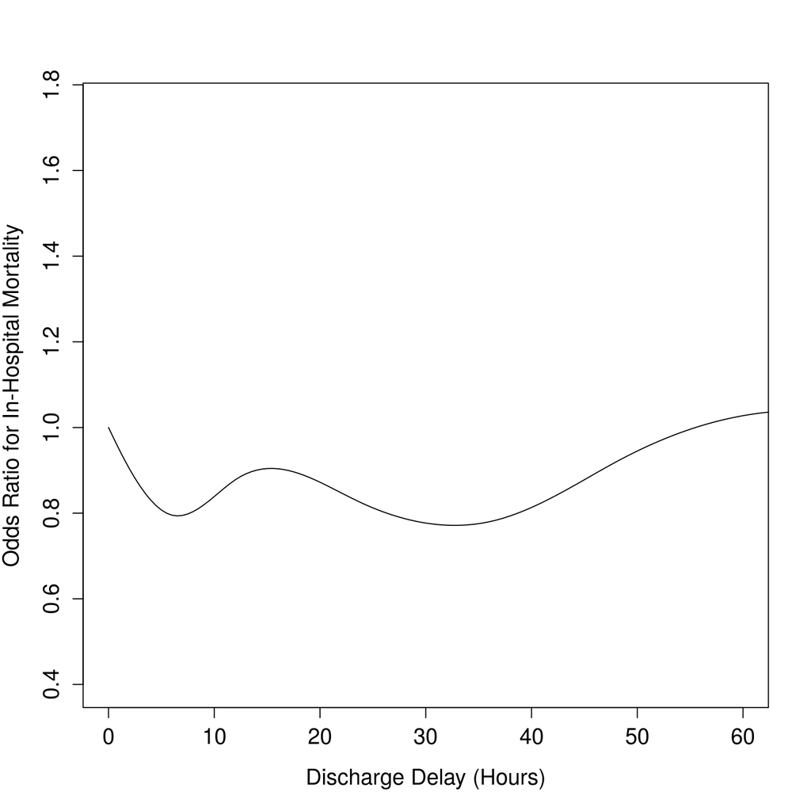

a

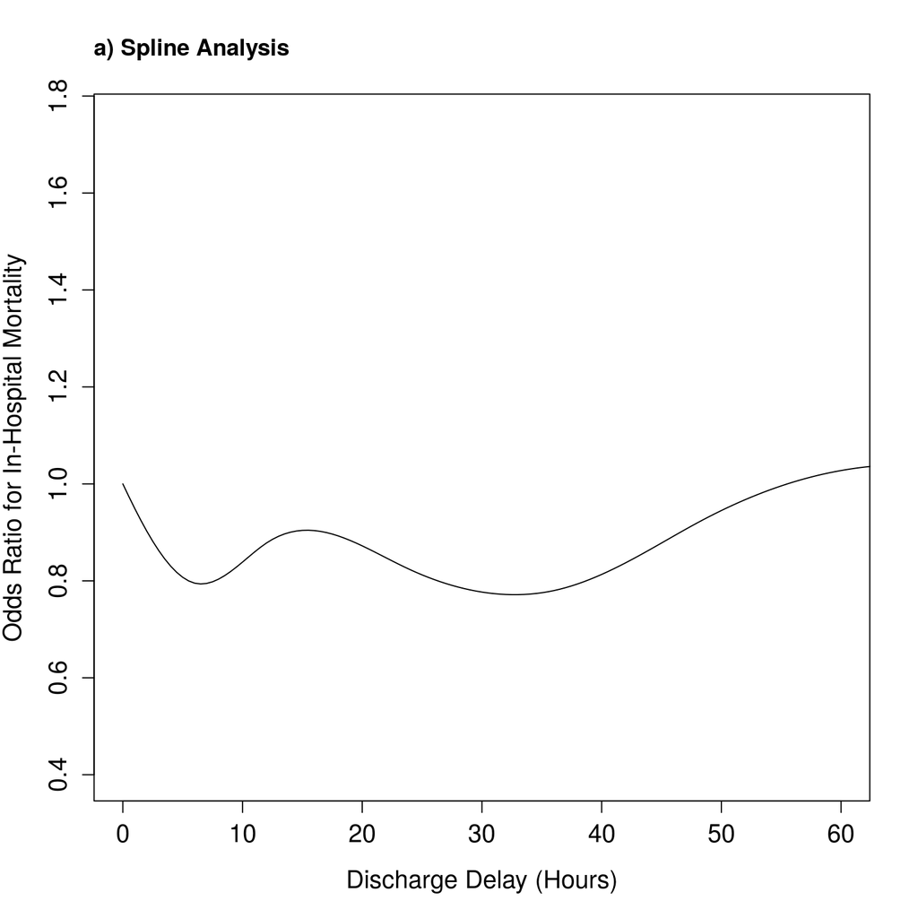

a

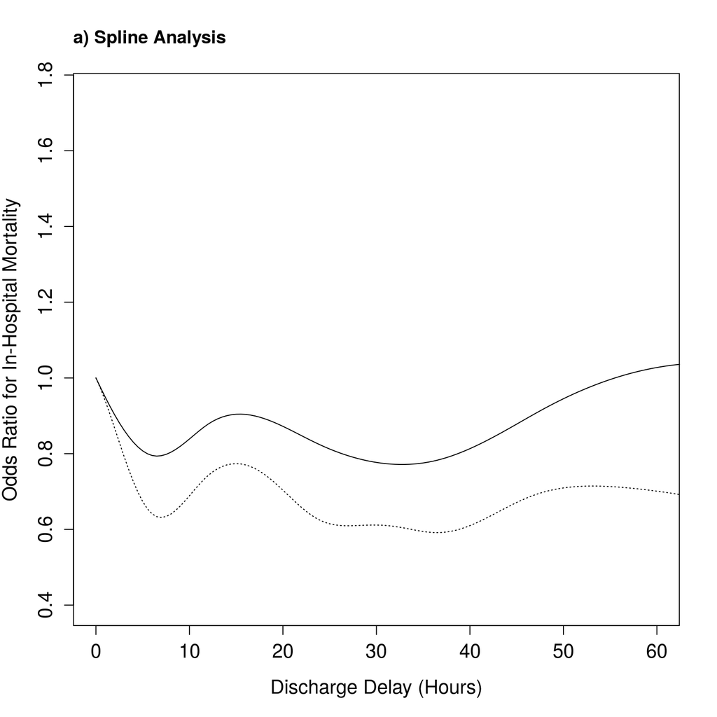

a

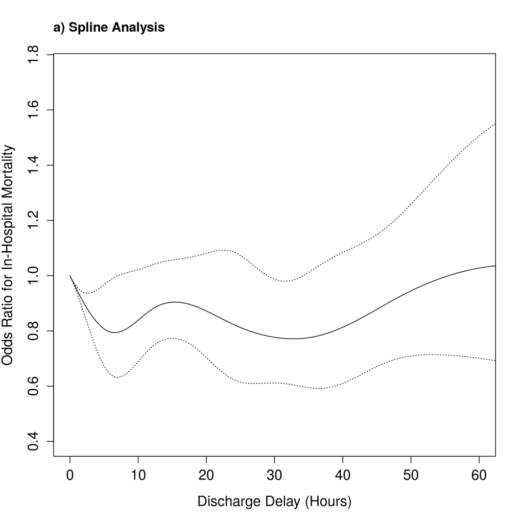

a

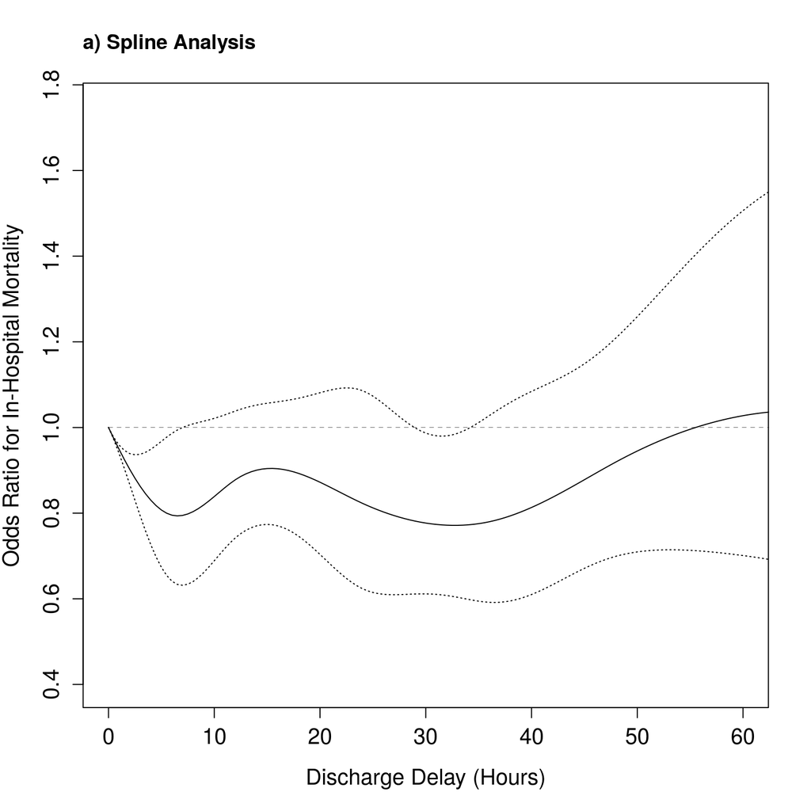

a

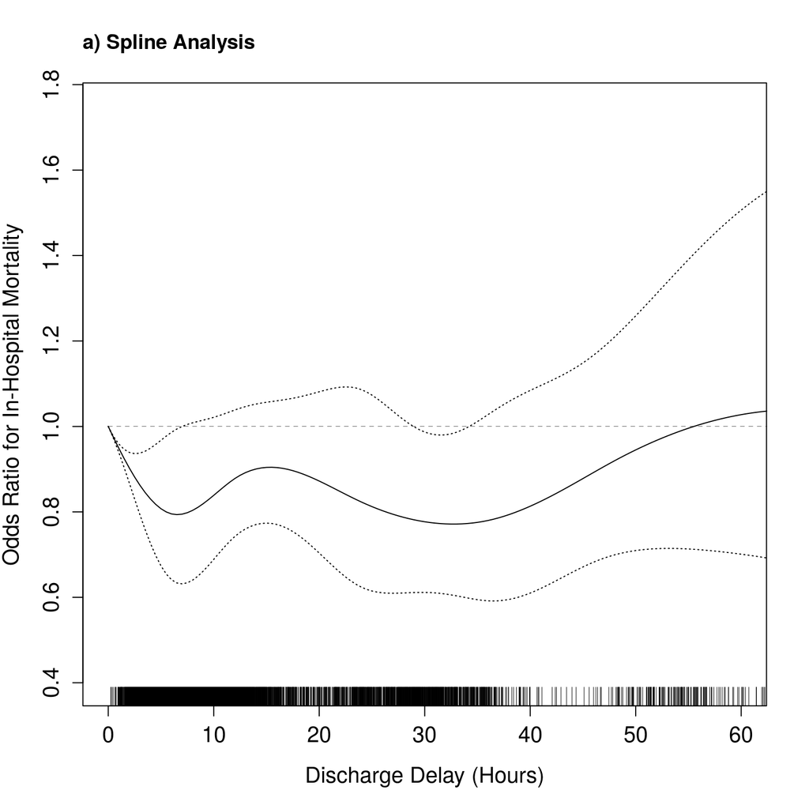

a

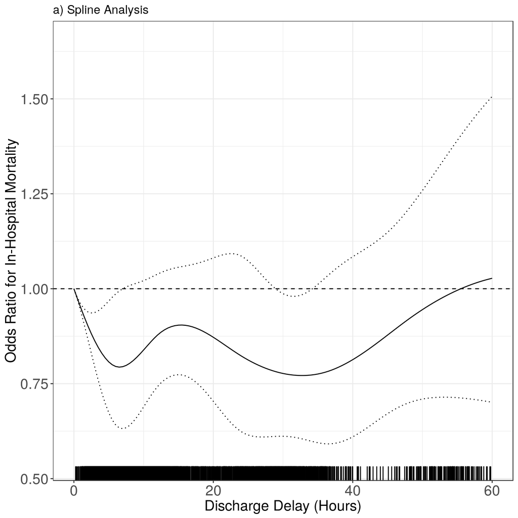

a

Below is a similar approach to the splines, but using gam (penalized splines chosen) just for a last look at this. Indeed, the wiggleness goes away.

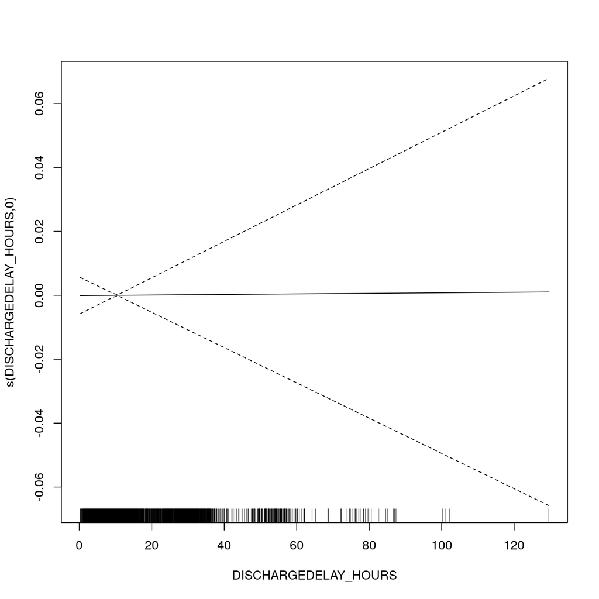

```
##
## Family: binomial
## Link function: logit
##
## Formula:
## hospitaldeath ~ s(DISCHARGEDELAY_HOURS, k = 10, bs = "ts") +
##     +cut2(oasis, g = 3) + cut2(age_nohipaa, g = 3) + female +
##     request_tele + request_resp + request_mrsa + request_vre +
##     request_cdiff + cut2(elixhauser_hospital, g = 3) + cut2(los_pre_callout_days,
##     c(1, 3, 7, 28)) + as.factor(callout_month) + as.factor(callout_year) +
##     as.factor(callout_dayofweek) + as.factor(callout_wardid ==
##     1) * cut2(PROPFULL_BEDS, c(0.9, 1)) + MED_SERVICE + relevel(cut2(hourofcallout2,
##     c(7, 12, 19)), "[ 7.000,12.000)")
##
## Parametric coefficients:
##                                                                                Estimate
## (Intercept)                                                                    -4.08157
## cut2(oasis, g = 3)[27,34)                                                       0.66717
## cut2(oasis, g = 3)[34,64]                                                       1.38135
## cut2(age_nohipaa, g = 3)[56.1, 73.8)                                            0.06868
## cut2(age_nohipaa, g = 3)[73.8,104.4]                                            0.17876
## female                                                                         -0.16410
## request_tele                                                                   -0.31412
## request_resp                                                                   -0.09673
## request_mrsa                                                                   -0.07257
## request_vre                                                                     0.66098
## request_cdiff                                                                   0.40339
## cut2(elixhauser_hospital, g = 3)[  1, 7)                                        0.71793
## cut2(elixhauser_hospital, g = 3)[  7,31]                                        1.27415
## cut2(los_pre_callout_days, c(1, 3, 7, 28))[  1.000,  3.000)                    -0.07079
## cut2(los_pre_callout_days, c(1, 3, 7, 28))[  3.000,  7.000)                     0.52310
## cut2(los_pre_callout_days, c(1, 3, 7, 28))[  7.000, 28.000)                     0.88529
## cut2(los_pre_callout_days, c(1, 3, 7, 28))[ 28.000,130.762]                     2.44058
## as.factor(callout_month)2                                                       0.04335
## as.factor(callout_month)3                                                       0.29207
## as.factor(callout_month)4                                                       0.16750
## as.factor(callout_month)5                                                       0.04143
## as.factor(callout_month)6                                                       0.04561
## as.factor(callout_month)7                                                       0.05085
## as.factor(callout_month)8                                                       0.25779
```

[output cut: 219 more lines]

```
## MED_SERVICETRUE
## relevel(cut2(hourofcallout2, c(7, 12, 19)), "[ 7.000,12.000)")[ 0.117, 7.000)  *
## relevel(cut2(hourofcallout2, c(7, 12, 19)), "[ 7.000,12.000)")[12.000,19.000)
## relevel(cut2(hourofcallout2, c(7, 12, 19)), "[ 7.000,12.000)")[19.000,23.867]
## as.factor(callout_wardid == 1)TRUE:cut2(PROPFULL_BEDS, c(0.9, 1))[0.900,1.000)
## as.factor(callout_wardid == 1)TRUE:cut2(PROPFULL_BEDS, c(0.9, 1))[1.000,1.093]
## ---
## Signif. codes:  0 '***' 0.001 '**' 0.01 '*' 0.05 '.' 0.1 ' ' 1
##
## Approximate significance of smooth terms:
##                              edf Ref.df Chi.sq p-value
## s(DISCHARGEDELAY_HOURS) 0.004211      9  0.001   0.636
##
## R-sq.(adj) =  0.0693   Deviance explained =   14%
## UBRE = -0.62303  Scale est. = 1         n = 9673
```

```
##
## Family: binomial
## Link function: logit
##
## Formula:
## hospitaldeath ~ s(DISCHARGEDELAY_HOURS, k = 10, bs = "ts") +
##     +cut2(oasis, g = 3) + cut2(age_nohipaa, g = 3) + female +
##     request_tele + request_resp + request_mrsa + request_vre +
##     request_cdiff + cut2(elixhauser_hospital, g = 3) + cut2(los_pre_callout_days,
##     c(1, 3, 7, 28)) + as.factor(callout_month) + as.factor(callout_year) +
##     as.factor(callout_dayofweek) + as.factor(callout_wardid ==
##     1) * cut2(PROPFULL_BEDS, c(0.9, 1)) + MED_SERVICE + relevel(cut2(hourofcallout2,
##     c(7, 12, 19)), "[ 7.000,12.000)")
##
## Parametric Terms:
##                                                                df  Chi.sq
## cut2(oasis, g = 3)                                              2 105.750
## cut2(age_nohipaa, g = 3)                                        2   2.064
## female                                                          1   3.017
## request_tele                                                    1   9.393
## request_resp                                                    1   0.050
## request_mrsa                                                    1   0.282
## request_vre                                                     1  15.934
## request_cdiff                                                   1   6.013
## cut2(elixhauser_hospital, g = 3)                                2  89.827
## cut2(los_pre_callout_days, c(1, 3, 7, 28))                      4 108.926
## as.factor(callout_month)                                       11  14.707
## as.factor(callout_year)                                         6  20.021
## as.factor(callout_dayofweek)                                    6   7.066
## as.factor(callout_wardid == 1)                                  1   7.619
## cut2(PROPFULL_BEDS, c(0.9, 1))                                  2   1.059
## MED_SERVICE                                                     1   2.666
## relevel(cut2(hourofcallout2, c(7, 12, 19)), "[ 7.000,12.000)")  3   6.411
## as.factor(callout_wardid == 1):cut2(PROPFULL_BEDS, c(0.9, 1))   2   2.050
##                                                                 p-value
## cut2(oasis, g = 3)                                              < 2e-16
## cut2(age_nohipaa, g = 3)                                        0.35630
## female                                                          0.08238
## request_tele                                                    0.00218
## request_resp                                                    0.82256
## request_mrsa                                                    0.59552
## request_vre                                                    6.56e-05
## request_cdiff                                                   0.01420
## cut2(elixhauser_hospital, g = 3)                                < 2e-16
## cut2(los_pre_callout_days, c(1, 3, 7, 28))                      < 2e-16
## as.factor(callout_month)                                        0.19629
## as.factor(callout_year)                                         0.00275
## as.factor(callout_dayofweek)                                    0.31476
## as.factor(callout_wardid == 1)                                  0.00577
## cut2(PROPFULL_BEDS, c(0.9, 1))                                  0.58903
## MED_SERVICE                                                     0.10254
## relevel(cut2(hourofcallout2, c(7, 12, 19)), "[ 7.000,12.000)")  0.09325
## as.factor(callout_wardid == 1):cut2(PROPFULL_BEDS, c(0.9, 1))   0.35880
##
## Approximate significance of smooth terms:
##                              edf   Ref.df Chi.sq p-value
## s(DISCHARGEDELAY_HOURS) 0.004211 9.000000  0.001   0.636
```